# TSA project - Forecasting financial instrument prices with VECM and ARIMA models

### ARIMA(1,1,1)

```r
arima111 <- Arima(chosen_ones$first, order = c(1, 1, 1))

coeftest(arima111)
```

```
##
## z test of coefficients:
##
##      Estimate Std. Error z value Pr(>|z|)
## ar1  0.018087   0.043685   0.414   0.6788
## ma1 -0.703040   0.029246 -24.039   <2e-16 ***
## ---
## Signif. codes:  0 '***' 0.001 '**' 0.01 '*' 0.05 '.' 0.1 ' ' 1
```

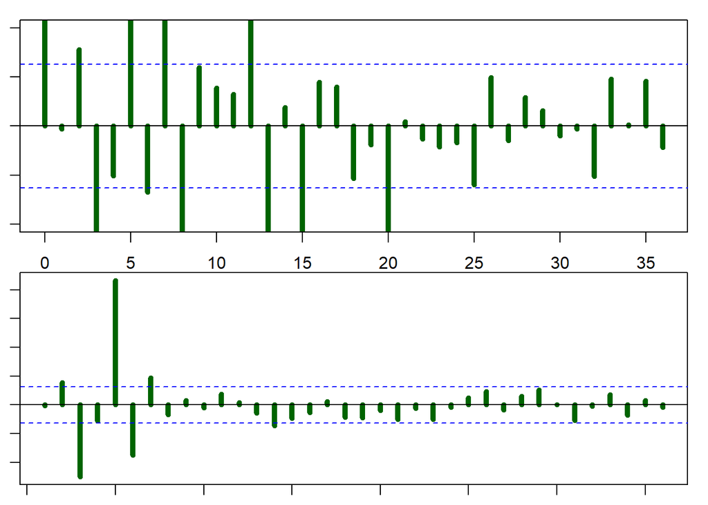

```r
par(mar = c(1, 1, 1, 1))
plot_ACF_PACF_resids(arima111)
```

ACF and PACF plots shows that some lags are still significant

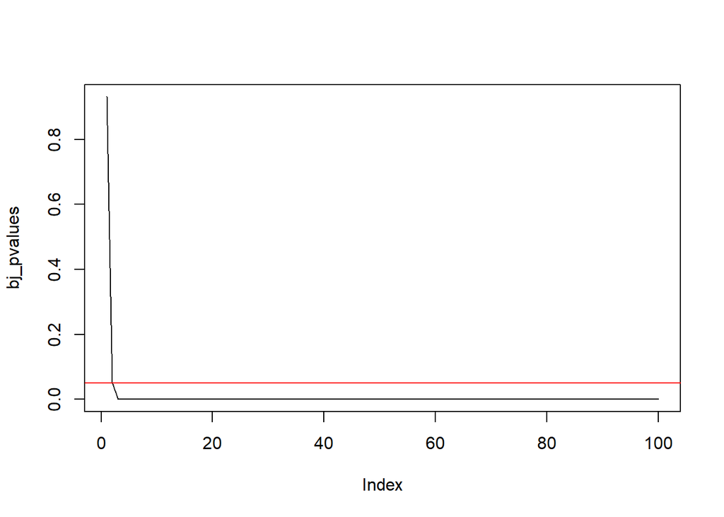

```r
bj_pvalues = c()
for(i in c(1:100)){
  bj = Box.test(resid(arima111), type = "Ljung-Box", lag = i)
  bj_pvalues = append(bj_pvalues,bj$p.value)
}
plot(bj_pvalues, type='l')
abline(h=0.05, col='red', type='l')
```

The residuals are **not** white noise

### ARIMA(7,1,3)

```r
arima713 <- Arima(chosen_ones$first,
                  order = c(7, 1, 3),
                  include.constant = TRUE,
                  optim.control = list(maxit = 800),
                  optim.method = "L-BFGS-B")

arima713
```

```
## Series: chosen_ones$first
## ARIMA(7,1,3) with drift
##
## Coefficients:
##           ar1      ar2      ar3      ar4      ar5      ar6     ar7     ma1
##       -0.6514  -1.1541  -1.4429  -0.8719  -0.4142  -0.5870  0.0088  0.0882
## s.e.   0.0907   0.0457   0.1057   0.1179   0.0787   0.0479  0.0593  0.0856
##          ma2     ma3   drift
##       0.8438  0.4416  0.0143
## s.e.  0.0332  0.0851  0.0127
##
## sigma^2 = 1.048:  log likelihood = -1394.8
## AIC=2813.6   AICc=2813.92   BIC=2872.11
```

```r
coeftest(arima713)
```

```
##
## z test of coefficients:
##
##         Estimate Std. Error  z value           Pr(>|z|)
## ar1   -0.6513562  0.0907462  -7.1778 0.0000000000007085 ***
## ar2   -1.1540782  0.0456852 -25.2615          < 2.2e-16 ***
## ar3   -1.4429095  0.1057496 -13.6446          < 2.2e-16 ***
## ar4   -0.8718718  0.1179292  -7.3932 0.0000000000001434 ***
## ar5   -0.4141960  0.0787221  -5.2615 0.0000001428872375 ***
## ar6   -0.5870440  0.0479309 -12.2477          < 2.2e-16 ***
## ar7    0.0088007  0.0593061   0.1484             0.8820
## ma1    0.0882290  0.0856368   1.0303             0.3029
## ma2    0.8437924  0.0332343  25.3892          < 2.2e-16 ***
## ma3    0.4415985  0.0850646   5.1913 0.0000002087985680 ***
## drift  0.0143384  0.0127151   1.1277             0.2595
## ---
## Signif. codes:  0 '***' 0.001 '**' 0.01 '*' 0.05 '.' 0.1 ' ' 1
```

only ar7 and ma1 are statistically insignificant (and drift)

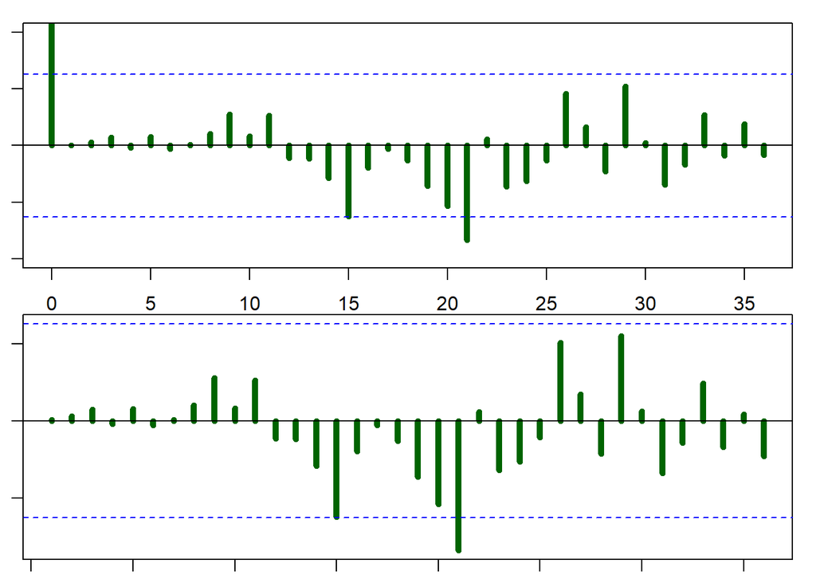

```r
par(mar = c(1, 1, 1, 1))
plot_ACF_PACF_resids(arima713)
```

lags 15, 21 still significant

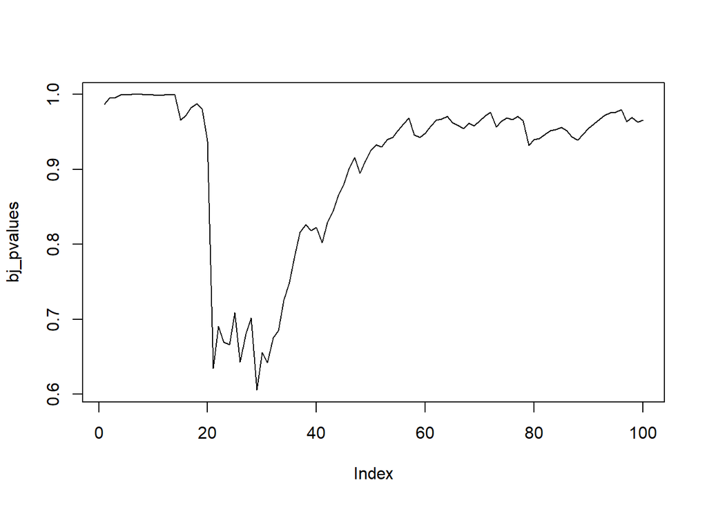

```r
bj_pvalues = c()
for(i in c(1:100)){
  bj = Box.test(resid(arima713), type = "Ljung-Box", lag = i)
  bj_pvalues = append(bj_pvalues,bj$p.value)
}
plot(bj_pvalues, type='l')
abline(h=0.05, col='red', type='l')
```

residuals are white noise

### ARIMA(7,1,15)

```r
arima7115 <- Arima(chosen_ones$first, order = c(7, 1, 15))

arima7115
```

```
## Series: chosen_ones$first
## ARIMA(7,1,15)
##
## Coefficients:
##           ar1     ar2      ar3      ar4     ar5     ar6      ar7      ma1
##       -0.0543  0.2135  -0.4980  -0.1948  0.6479  0.1264  -0.0774  -0.5134
## s.e.   0.4427  0.4556   0.1243   0.3563  0.2086  0.3442   0.3210   0.4418
##           ma2     ma3     ma4      ma5      ma6     ma7     ma8     ma9    ma10
##       -0.1940  0.2443  0.0099  -0.2816  -0.1945  0.2183  0.1171  0.0954  -0.161
## s.e.   0.6769  0.2471  0.2207   0.1760   0.1292  0.1097  0.1168  0.0783   0.096
##          ma11    ma12    ma13    ma14     ma15
##       -0.0398  0.0422  0.0315  0.0475  -0.1553
## s.e.   0.0787  0.0785  0.0513  0.0545   0.0461
##
## sigma^2 = 1.052:  log likelihood = -1389.87
## AIC=2825.74   AICc=2826.91   BIC=2937.9
```

```r
coeftest(arima7115)
```

```
##
## z test of coefficients:
##
##        Estimate Std. Error z value   Pr(>|z|)
## ar1  -0.0542684  0.4426756 -0.1226  0.9024304
## ar2   0.2134859  0.4556494  0.4685  0.6394049
## ar3  -0.4979671  0.1242778 -4.0069 0.00006152 ***
## ar4  -0.1947513  0.3563475 -0.5465  0.5847080
## ar5   0.6478640  0.2085970  3.1058  0.0018975 **
## ar6   0.1264485  0.3441708  0.3674  0.7133204
## ar7  -0.0774130  0.3210462 -0.2411  0.8094564
## ma1  -0.5133574  0.4417798 -1.1620  0.2452269
## ma2  -0.1940442  0.6768938 -0.2867  0.7743661
## ma3   0.2442709  0.2471286  0.9884  0.3229389
## ma4   0.0099034  0.2206659  0.0449  0.9642033
## ma5  -0.2816042  0.1760500 -1.5996  0.1096941
## ma6  -0.1945218  0.1291882 -1.5057  0.1321379
## ma7   0.2182510  0.1096790  1.9899  0.0466011 *
## ma8   0.1171405  0.1167682  1.0032  0.3157699
## ma9   0.0954481  0.0782767  1.2194  0.2227049
## ma10 -0.1609588  0.0959950 -1.6767  0.0935929 .
## ma11 -0.0397693  0.0786969 -0.5053  0.6133142
## ma12  0.0421535  0.0785395  0.5367  0.5914628
## ma13  0.0315051  0.0512881  0.6143  0.5390324
## ma14  0.0474573  0.0545495  0.8700  0.3843081
## ma15 -0.1553275  0.0461161 -3.3682  0.0007566 ***
## ---
## Signif. codes:  0 '***' 0.001 '**' 0.01 '*' 0.05 '.' 0.1 ' ' 1
```

ar3, ar5 and ma7 and ma15 are statistically significant

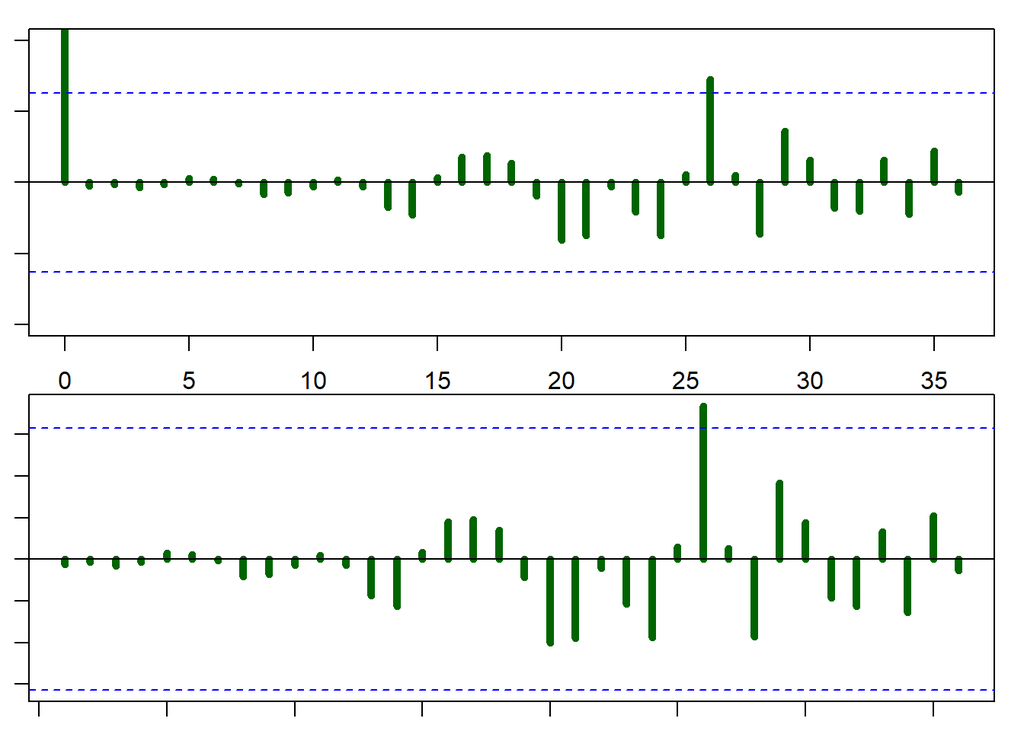

```r
par(mar = c(1, 1, 1, 1))
plot_ACF_PACF_resids(arima7115)
```

lags 26 is on significance line

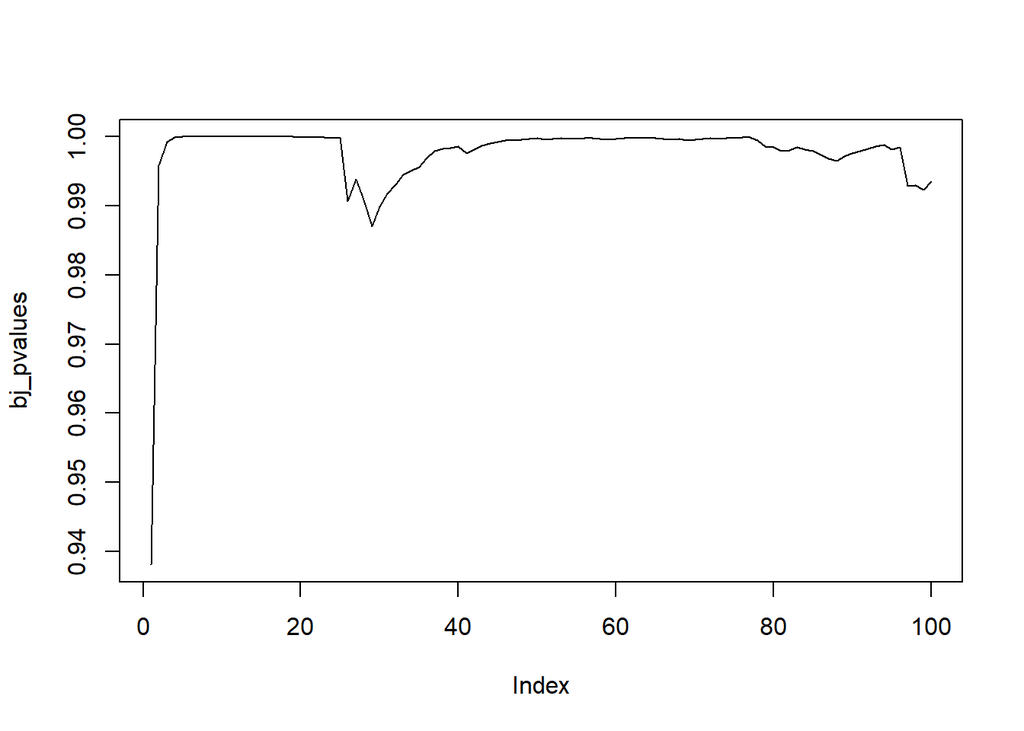

```r
bj_pvalues = c()
for(i in c(1:100)){
  bj = Box.test(resid(arima7115), type = "Ljung-Box", lag = i)
  bj_pvalues = append(bj_pvalues,bj$p.value)
}
plot(bj_pvalues, type='l')
abline(h=0.05, col='red', type='l')
```

residuals are white noise

### ARIMA(7,1,26)

```r
arima7126 <- Arima(chosen_ones$first,
                    order = c(7, 1, 26),
                    include.constant = TRUE,
                    optim.control = list(maxit = 800),
                    optim.method = "L-BFGS-B")

coeftest(arima7126)
```

```
##
## z test of coefficients:
##
##         Estimate Std. Error z value    Pr(>|z|)
## ar1   -0.7925834  0.1974270 -4.0146 0.000059556 ***
## ar2   -1.0256675  0.2840144 -3.6113   0.0003046 ***
## ar3    0.1223353  0.2582605  0.4737   0.6357214
## ar4    0.5822561  0.1793381  3.2467   0.0011675 **
## ar5    0.9424590  0.1717786  5.4865 0.000000041 ***
## ar6    0.5713710  0.1716359  3.3290   0.0008717 ***
## ar7    0.4362021  0.3684597  1.1839   0.2364713
## ma1    0.2261617  0.1951590  1.1589   0.2465137
## ma2    0.6408677  0.3629253  1.7658   0.0774228 .
## ma3   -1.0601150  0.4178241 -2.5372   0.0111734 *
## ma4   -0.6443724  0.3684523 -1.7489   0.0803148 .
## ma5   -0.5432354  0.3571306 -1.5211   0.1282319
## ma6    0.1794257  0.3078804  0.5828   0.5600432
## ma7    0.4512994  0.4552010  0.9914   0.3214763
## ma8    0.0059676  0.3711470  0.0161   0.9871714
## ma9    0.0238869  0.2225296  0.1073   0.9145172
## ma10  -0.3642730  0.3516962 -1.0358   0.3003139
## ma11   0.1568553  0.2620197  0.5986   0.5494134
## ma12   0.0454726  0.1751991  0.2595   0.7952125
## ma13   0.0890737  0.1743489  0.5109   0.6094256
## ma14  -0.0655215  0.1292570 -0.5069   0.6122190
## ma15  -0.2759385  0.1715647 -1.6084   0.1077555
## ma16   0.0207773  0.2448496  0.0849   0.9323749
## ma17  -0.0596270  0.1432453 -0.4163   0.6772210
## ma18   0.2043392  0.1819536  1.1230   0.2614251
## ma19  -0.0101953  0.1235096 -0.0825   0.9342119
## ma20  -0.0689265  0.1207906 -0.5706   0.5682516
## ma21  -0.1165240  0.0831850 -1.4008   0.1612794
## ma22  -0.0368118  0.1660196 -0.2217   0.8245227
## ma23   0.1223753  0.1116132  1.0964   0.2728936
## ma24   0.0795205  0.0617737  1.2873   0.1979943
## ma25   0.0731069  0.1147262  0.6372   0.5239758
## ma26  -0.0142818  0.0517249 -0.2761   0.7824631
## drift  0.0137456  0.0115705  1.1880   0.2348361
## ---
## Signif. codes:  0 '***' 0.001 '**' 0.01 '*' 0.05 '.' 0.1 ' ' 1
```

ar1, ar2, ar4, ar5, ar6 and ma3 statistically significant

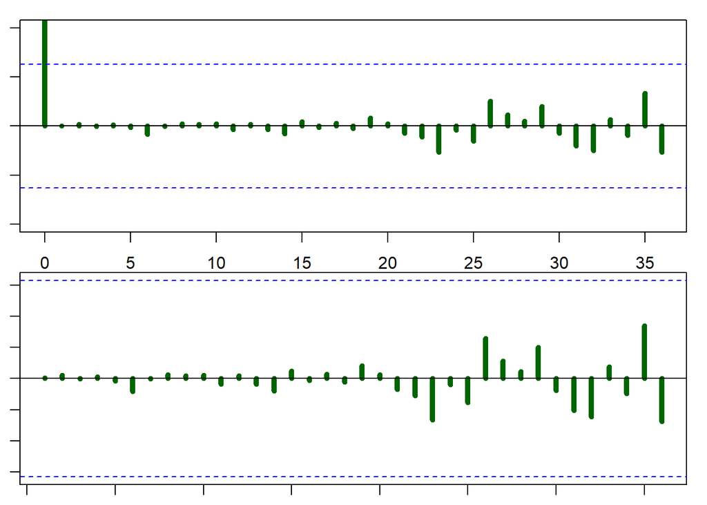

```r
par(mar = c(1, 1, 1, 1))
plot_ACF_PACF_resids(arima7126)
```

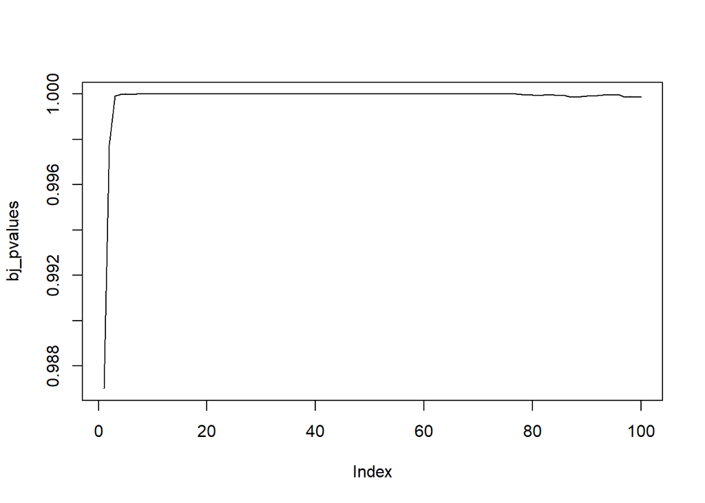

```r
bj_pvalues = c()
for(i in c(1:100)){
  bj = Box.test(resid(arima7126), type = "Ljung-Box", lag = i)
  bj_pvalues = append(bj_pvalues,bj$p.value)
}
plot(bj_pvalues, type='l')
abline(h=0.05, col='red', type='l')
```

residuals are white noise

**Now lets use previous models but lets set nonsignificant variables to 0 (arima713fixed but without last ar term)**

```r
arima613fixed <- Arima(chosen_ones$first,
                    order = c(6, 1, 3),
                    fixed = c(NA, NA, NA, NA, NA, NA,
                              0, NA, NA))

coeftest(arima613fixed)
```

```
##
## z test of coefficients:
##
##      Estimate Std. Error  z value Pr(>|z|)
## ar1 -0.559166   0.032085 -17.4276   <2e-16 ***
## ar2  0.177060   0.405748   0.4364   0.6626
## ar3 -0.164680   0.413806  -0.3980   0.6907
## ar4 -0.184656   0.212880  -0.8674   0.3857
## ar5  0.414115   0.252677   1.6389   0.1012
## ar6  0.136010   0.237630   0.5724   0.5671
## ma2 -0.440078   0.407594  -1.0797   0.2803
## ma3 -0.086580   0.192761  -0.4492   0.6533
## ---
## Signif. codes:  0 '***' 0.001 '**' 0.01 '*' 0.05 '.' 0.1 ' ' 1
```

nothing expect ar1 is significant

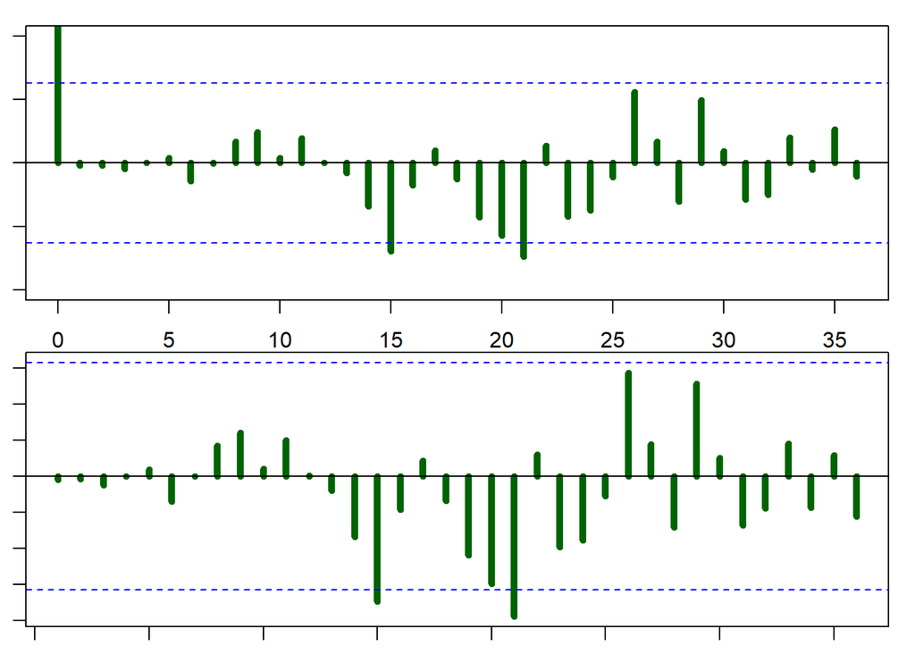

```r
par(mar = c(1, 1, 1, 1))
plot_ACF_PACF_resids(arima613fixed)
```

we still have some other lags significant

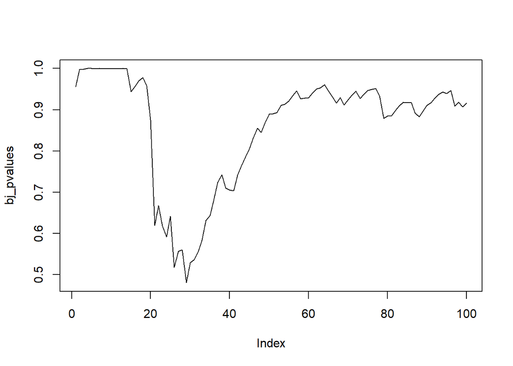

```r
bj_pvalues = c()
for(i in c(1:100)){
  bj = Box.test(resid(arima613fixed), type = "Ljung-Box", lag = i)
  bj_pvalues = append(bj_pvalues,bj$p.value)
}
plot(bj_pvalues, type='l')
abline(h=0.05, col='red', type='l')
```

### arima7115 with nonsignificant variables set to 0 (expect ma10) (its arima5115)

```r
arima5115fixed <- Arima(chosen_ones$first,
                       order = c(5, 1, 15),
                       fixed = c(0, 0, NA, 0, NA,
                                 0,0,0,0,0,0,NA,0,0,NA,0,0,0,0,NA))

coeftest(arima5115fixed)
```

```
##
## z test of coefficients:
##
##       Estimate Std. Error  z value       Pr(>|z|)
## ar3  -0.309078   0.027304 -11.3197      < 2.2e-16 ***
## ar5   0.457349   0.029423  15.5438      < 2.2e-16 ***
## ma7   0.185142   0.030487   6.0728 0.000000001257 ***
## ma10 -0.098609   0.034052  -2.8958       0.003782 **
## ma15 -0.130142   0.031326  -4.1544 0.000032608266 ***
## ---
## Signif. codes:  0 '***' 0.001 '**' 0.01 '*' 0.05 '.' 0.1 ' ' 1
```

everything is significant

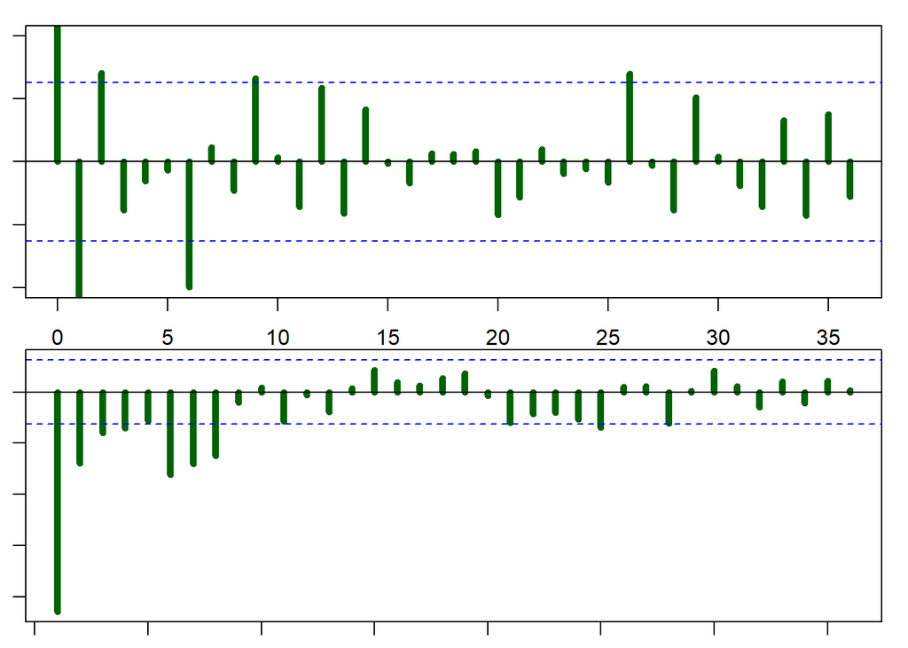

```r
par(mar = c(1, 1, 1, 1))
plot_ACF_PACF_resids(arima5115fixed)
```

we still have some other lags significant

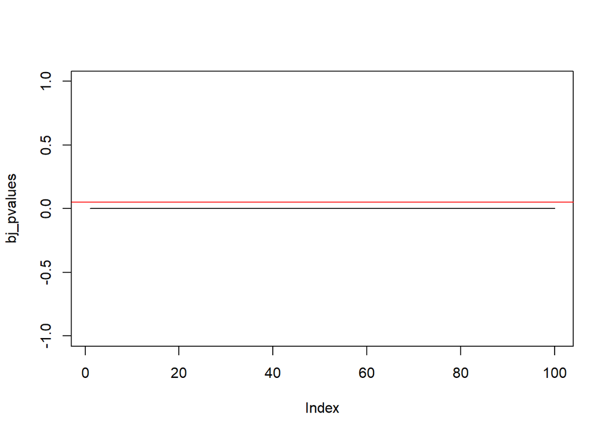

```r
bj_pvalues = c()
for(i in c(1:100)){
  bj = Box.test(resid(arima5115fixed), type = "Ljung-Box", lag = i)
  bj_pvalues = append(bj_pvalues,bj$p.value)
}
plot(bj_pvalues, type='l')
abline(h=0.05, col='red', type='l')
```

residuals are **not** white noise!!!!

### lets try arima7126 with nonsignificant variables set to 0 (its arima614) lets include ma2 and ma4

```r
arima614fixed <- Arima(chosen_ones$first,
                       order = c(6, 1, 4),
                       fixed = c(NA, NA, 0, NA, NA, NA,
                                 0,NA,NA,NA))

coeftest(arima614fixed)
```

```
##
## z test of coefficients:
##
##      Estimate Std. Error  z value        Pr(>|z|)
## ar1 -0.558580   0.032219 -17.3369       < 2.2e-16 ***
## ar2  0.332216   0.052330   6.3485 0.0000000002174 ***
## ar4 -0.087630   0.059192  -1.4804          0.1388
## ar5  0.518577   0.053593   9.6763       < 2.2e-16 ***
## ar6  0.227476   0.041661   5.4602 0.0000000475713 ***
## ma2 -0.596222   0.060716  -9.8199       < 2.2e-16 ***
## ma3 -0.170288   0.038999  -4.3665 0.0000126267667 ***
## ma4 -0.018873   0.059840  -0.3154          0.7525
## ---
## Signif. codes:  0 '***' 0.001 '**' 0.01 '*' 0.05 '.' 0.1 ' ' 1
```

ar4 and ma4 are not significant

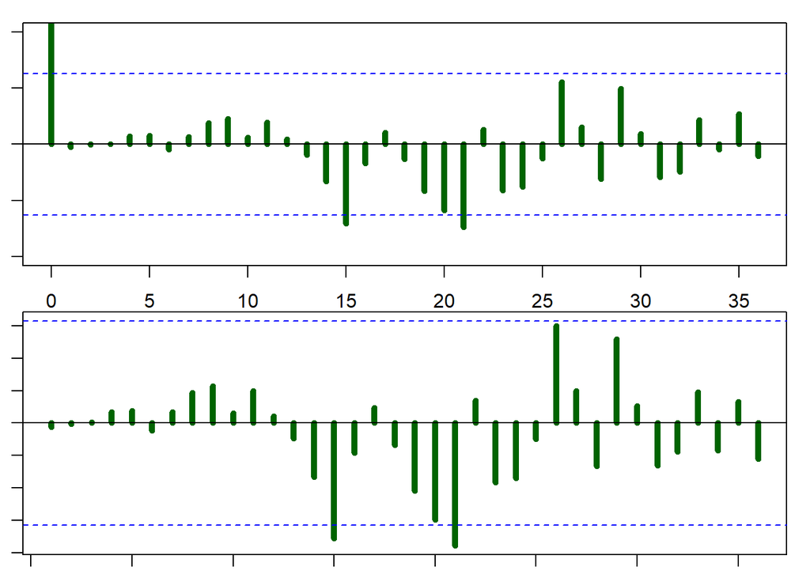

```r
par(mar = c(1, 1, 1, 1))
plot_ACF_PACF_resids(arima614fixed)
```

lag 15,20,21,26 on significance line

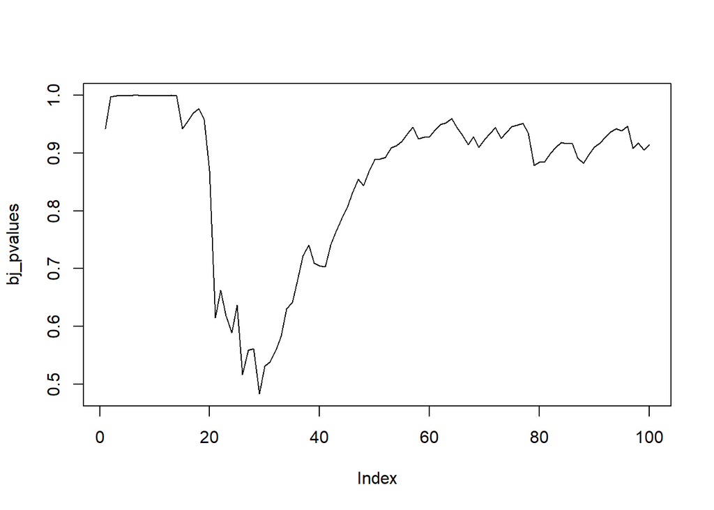

```r
bj_pvalues = c()
for(i in c(1:100)){
  bj = Box.test(resid(arima614fixed), type = "Ljung-Box", lag = i)
  bj_pvalues = append(bj_pvalues,bj$p.value)
}
plot(bj_pvalues, type='l')
abline(h=0.05, col='red', type='l')
```

residuals are white noise

### lets set to 0 nonsignificant variables from previous model (its arima 613 now)

```r
arima613fixed <- Arima(chosen_ones$first,
                        order = c(6, 1, 3),
                        fixed = c(NA, NA, 0, 0, NA, NA,
                                  0, NA, NA))

coeftest(arima613fixed)
```

```
##
## z test of coefficients:
##
##      Estimate Std. Error  z value       Pr(>|z|)
## ar1 -0.544074   0.030795 -17.6676      < 2.2e-16 ***
## ar2  0.283939   0.049178   5.7737 0.000000007754 ***
## ar5  0.557968   0.040020  13.9421      < 2.2e-16 ***
## ar6  0.196770   0.038908   5.0574 0.000000425096 ***
## ma2 -0.587025   0.061660  -9.5204      < 2.2e-16 ***
## ma3 -0.207290   0.036263  -5.7163 0.000000010888 ***
## ---
## Signif. codes:  0 '***' 0.001 '**' 0.01 '*' 0.05 '.' 0.1 ' ' 1
```

everything significant

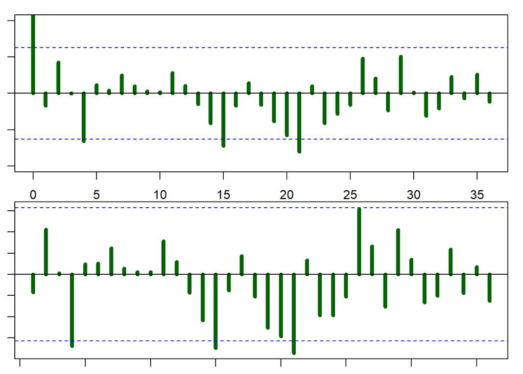

```r
par(mar = c(1, 1, 1, 1))
plot_ACF_PACF_resids(arima613fixed)
```

lag 4, 15, 20, 21 and 26 on line

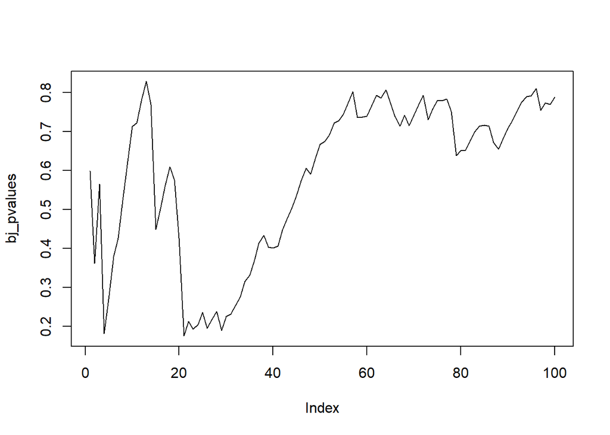

```r
bj_pvalues = c()
for(i in c(1:100)){
  bj = Box.test(resid(arima613fixed), type = "Ljung-Box", lag = i)
  bj_pvalues = append(bj_pvalues,bj$p.value)
}
plot(bj_pvalues, type='l')
abline(h=0.05, col='red', type='l')
```

residuals are white noise

### lets add AR(4) to the last model

```r
arima613fixed2 <- Arima(chosen_ones$first,
                       order = c(6, 1, 3),
                       fixed = c(NA, NA, 0, NA, NA, NA,
                                 0, NA, NA))

coeftest(arima613fixed2)
```

```
##
## z test of coefficients:
##
##      Estimate Std. Error  z value        Pr(>|z|)
## ar1 -0.560003   0.031855 -17.5797       < 2.2e-16 ***
## ar2  0.334098   0.052245   6.3948 0.0000000001608 ***
## ar4 -0.102669   0.035009  -2.9326        0.003361 **
## ar5  0.508100   0.042270  12.0205       < 2.2e-16 ***
## ar6  0.224881   0.040600   5.5390 0.0000000304226 ***
## ma2 -0.601492   0.058681 -10.2502       < 2.2e-16 ***
## ma3 -0.168077   0.039033  -4.3060 0.0000166199148 ***
## ---
## Signif. codes:  0 '***' 0.001 '**' 0.01 '*' 0.05 '.' 0.1 ' ' 1
```

everything significant

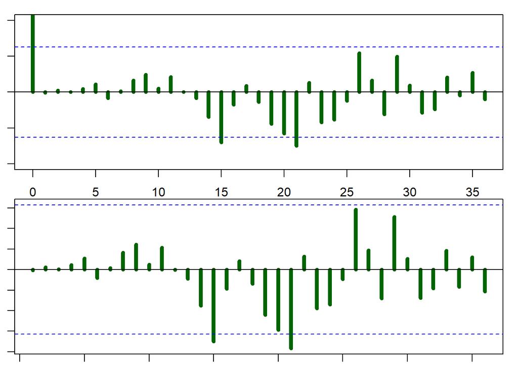

```r
par(mar = c(1, 1, 1, 1))
plot_ACF_PACF_resids(arima613fixed2)
```

lag 15, 20, 21 on line

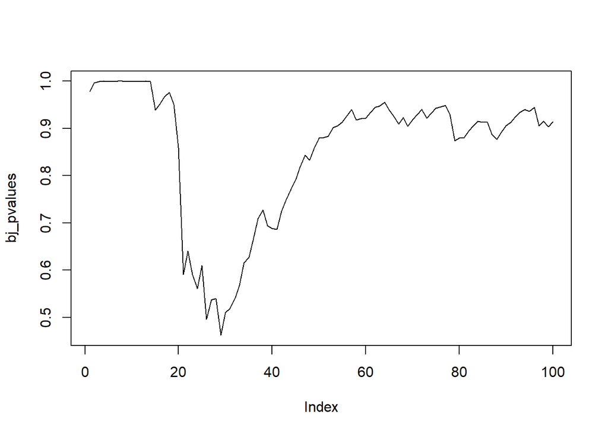

```r
bj_pvalues = c()
for(i in c(1:100)){
  bj = Box.test(resid(arima613fixed2), type = "Ljung-Box", lag = i)
  bj_pvalues = append(bj_pvalues,bj$p.value)
}
plot(bj_pvalues, type='l')
abline(h=0.05, col='red', type='l')
```

residuals are white noise

# 4 INFORMATION CRITERIAS

```r
AIC(arima111, arima713, arima7115, arima7126,
    arima613fixed, arima613fixed2, arima614fixed, arima5115fixed)
```

```
##                df      AIC
## arima111        3 3116.934
## arima713       12 2813.595
## arima7115      23 2825.745
## arima7126      35 2828.693
## arima613fixed   7 2819.385
## arima613fixed2  8 2812.690
## arima614fixed   9 2814.592
## arima5115fixed  6 3097.138
```

```r
BIC(arima111, arima713, arima7115, arima7126,
    arima613fixed, arima613fixed2, arima614fixed, arima5115fixed)
```

```
##                df      BIC
## arima111        3 3131.563
## arima713       12 2872.110
## arima7115      23 2937.899
## arima7126      35 2999.362
## arima613fixed   7 2853.519
## arima613fixed2  8 2851.700
## arima614fixed   9 2858.479
## arima5115fixed  6 3126.396
```

```r
arima613fixed2
```

```
## Series: chosen_ones$first
## ARIMA(6,1,3)
##
## Coefficients:
##           ar1     ar2  ar3      ar4     ar5     ar6  ma1      ma2      ma3
##       -0.5600  0.3341    0  -0.1027  0.5081  0.2249    0  -0.6015  -0.1681
## s.e.   0.0319  0.0522    0   0.0350  0.0423  0.0406    0   0.0587   0.0390
##
## sigma^2 = 1.055:  log likelihood = -1398.35
## AIC=2812.69   AICc=2812.84   BIC=2851.7
```

```r
coeftest(arima613fixed2)
```

```
##
## z test of coefficients:
##
##      Estimate Std. Error  z value        Pr(>|z|)
## ar1 -0.560003   0.031855 -17.5797       < 2.2e-16 ***
## ar2  0.334098   0.052245   6.3948 0.0000000001608 ***
## ar4 -0.102669   0.035009  -2.9326        0.003361 **
## ar5  0.508100   0.042270  12.0205       < 2.2e-16 ***
## ar6  0.224881   0.040600   5.5390 0.0000000304226 ***
## ma2 -0.601492   0.058681 -10.2502       < 2.2e-16 ***
## ma3 -0.168077   0.039033  -4.3060 0.0000166199148 ***
## ---
## Signif. codes:  0 '***' 0.001 '**' 0.01 '*' 0.05 '.' 0.1 ' ' 1
```

**Lets forecast 3 models with the lowest AIC arima613fixed2, arima713, arima614fixed**

```r
arima613fixed2_forecast <- forecast(arima613fixed2, h=30)
arima613fixed2_forecast
```

```
##      Point Forecast    Lo 80    Hi 80    Lo 95    Hi 95
##  971       140.3418 139.0255 141.6581 138.3287 142.3550
##  972       141.5612 140.1232 142.9993 139.3619 143.7606
##  973       141.6760 140.1019 143.2500 139.2687 144.0833
##  974       141.5161 139.9360 143.0963 139.0995 143.9327
##  975       141.3691 139.7599 142.9783 138.9081 143.8302
##  976       140.8140 139.0221 142.6060 138.0735 143.5546
##  977       141.4871 139.6298 143.3444 138.6467 144.3275
##  978       141.2737 139.2764 143.2709 138.2191 144.3282
##  979       141.5777 139.5663 143.5891 138.5016 144.6539
##  980       141.2825 139.2049 143.3601 138.1051 144.4599
##  981       141.1652 139.0258 143.3046 137.8933 144.4371
##  982       141.3713 139.1645 143.5781 137.9964 144.7463
##  983       141.2284 138.9337 143.5232 137.7189 144.7379
##  984       141.5141 139.1906 143.8376 137.9606 145.0676
```

[output cut: 16 more lines]

```r
arima613fixed2_forecast_data <- data.frame(f_mean  = as.numeric(arima613fixed2_forecast$mean),
                                           f_lower = as.numeric(arima613fixed2_forecast$lower[, 2]),
                                           f_upper = as.numeric(arima613fixed2_forecast$upper[, 2]))

arima613fixed2_forecast_data_xts <- xts(arima613fixed2_forecast_data, order.by = data_test$X)
```

```r
arima713_forecast <- forecast(arima713, h=30)
arima713_forecast
```

```
##      Point Forecast    Lo 80    Hi 80    Lo 95    Hi 95
##  971       140.4330 139.1201 141.7460 138.4250 142.4410
##  972       141.5254 140.0925 142.9584 139.3340 143.7169
##  973       141.6183 140.0465 143.1901 139.2145 144.0222
##  974       141.5758 139.9981 143.1535 139.1629 143.9887
##  975       141.5907 139.9834 143.1979 139.1326 144.0487
##  976       140.9812 139.1945 142.7679 138.2486 143.7137
##  977       141.4354 139.5845 143.2863 138.6047 144.2661
##  978       141.2595 139.2647 143.2544 138.2087 144.3104
##  979       141.7767 139.7665 143.7868 138.7024 144.8509
##  980       141.6261 139.5510 143.7011 138.4525 144.7996
##  981       141.3161 139.1826 143.4496 138.0532 144.5790
##  982       141.3564 139.1568 143.5560 137.9924 144.7204
##  983       141.3428 139.0494 143.6362 137.8353 144.8503
##  984       141.8644 139.5408 144.1881 138.3107 145.4182
```

[output cut: 16 more lines]

```r
arima713_forecast_data <- data.frame(f_mean  = as.numeric(arima713_forecast$mean),
                                     f_lower = as.numeric(arima713_forecast$lower[, 2]),
                                     f_upper = as.numeric(arima713_forecast$upper[, 2]))

arima713_forecast_data_xts <- xts(arima713_forecast_data, order.by = data_test$X)
```

```r
arima614fixed_forecast <- forecast(arima614fixed, h=30)
arima614fixed_forecast
```

```
##      Point Forecast    Lo 80    Hi 80    Lo 95    Hi 95
##  971       140.3454 139.0285 141.6623 138.3314 142.3595
##  972       141.5706 140.1311 143.0101 139.3690 143.7721
##  973       141.6884 140.1111 143.2656 139.2762 144.1005
##  974       141.5115 139.9280 143.0950 139.0898 143.9332
##  975       141.3566 139.7444 142.9688 138.8910 143.8222
##  976       140.8108 139.0145 142.6070 138.0636 143.5579
##  977       141.4913 139.6306 143.3519 138.6456 144.3369
##  978       141.2851 139.2867 143.2834 138.2289 144.3413
##  979       141.5750 139.5635 143.5865 138.4986 144.6513
##  980       141.2718 139.1952 143.3485 138.0958 144.4478
##  981       141.1595 139.0217 143.2974 137.8900 144.4291
##  982       141.3683 139.1637 143.5729 137.9967 144.7400
##  983       141.2369 138.9471 143.5267 137.7349 144.7388
##  984       141.5097 139.1924 143.8269 137.9657 145.0536
```

[output cut: 16 more lines]

```r
arima614fixed_forecast_data <- data.frame(f_mean  = as.numeric(arima614fixed_forecast$mean),
                                          f_lower = as.numeric(arima614fixed_forecast$lower[, 2]),
                                          f_upper = as.numeric(arima614fixed_forecast$upper[, 2]))

arima614fixed_forecast_data_xts <- xts(arima614fixed_forecast_data, order.by = data_test$X)
```

# 5 Forecast visualization

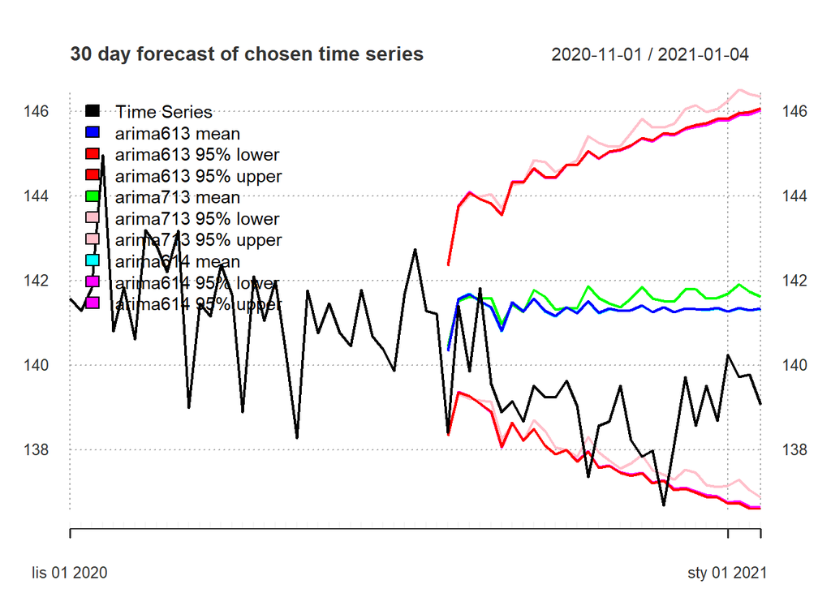

```r
data_all_xts <- rbind(data_train_xts[,3], data_test_xts[,3])
names(data_all_xts) <- "first"

ARIMA_forecasts_first <- merge(data_all_xts,
                               arima613fixed2_forecast_data_xts,
                               arima713_forecast_data_xts,
                               arima614fixed_forecast_data_xts)
names(ARIMA_forecasts_first) <- c("Time Series", "arima613 mean", "arima613 95% lower", "arima613 95% upper", "arima713 mean", "arima713 95% lower", "arima713 95% upper", "arima614 mean", "arima614 95% lower", "arima614 95% upper")

plot(ARIMA_forecasts_first["2020-11/",],
     major.ticks = "years",
     grid.ticks.on = "years",
     grid.ticks.lty = 3,
     main = "30 day forecast of chosen time series",
     col = c("black", "blue", "red", "red", "green", "pink", "pink", "cyan", "magenta", "magenta"),
     legend.loc = "topleft")
```

# 6 ARIMA for second time series (from before we know that this series is I(1))

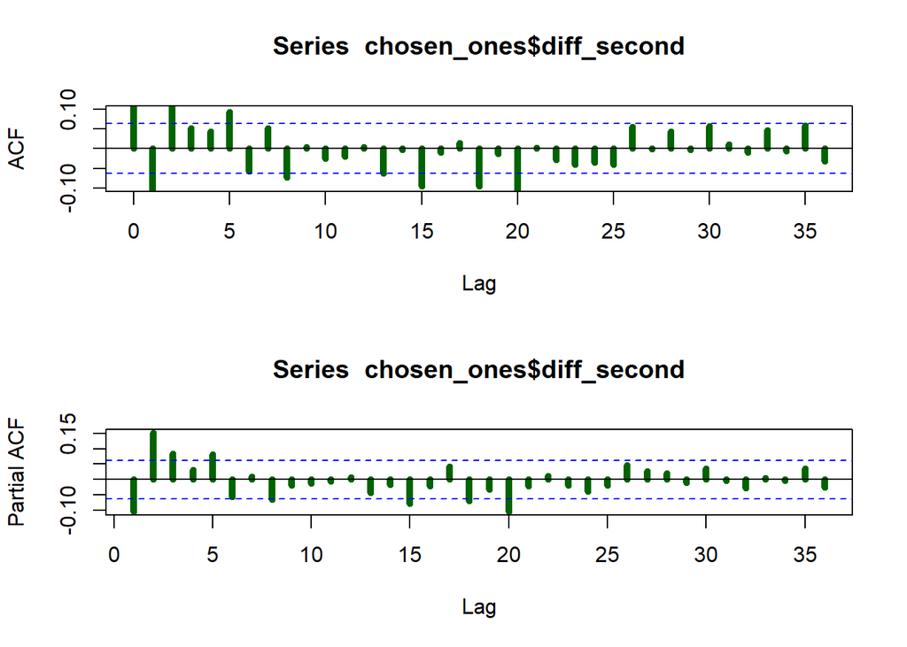

```r
par(mfrow = c(2, 1))
acf(chosen_ones$diff_second,
    lag.max = 36, # max lag for ACF
    ylim = c(-0.1, 0.1),   # limits for the y axis - we give c(min, max)
    lwd = 5,               # line width
    col = "dark green",
    na.action = na.pass)   # do not stop if there are missing values in the data
pacf(chosen_ones$diff_second,
     lag.max = 36,
     lwd = 5, col = "dark green",
     na.action = na.pass)
```

```r
par(mfrow = c(1, 1))
```

### lets start with checking ARIMA(1,1,1) and ARIMA(3,1,3)

### ARIMA(1,1,1)

```r
arima111_second <- Arima(chosen_ones$second, order = c(1, 1, 1))

coeftest(arima111_second)
```

```
##
## z test of coefficients:
##
##     Estimate Std. Error z value   Pr(>|z|)
## ar1 -0.52079    0.10800 -4.8221 0.00000142 ***
## ma1  0.40204    0.11329  3.5486  0.0003873 ***
## ---
## Signif. codes:  0 '***' 0.001 '**' 0.01 '*' 0.05 '.' 0.1 ' ' 1
```

all variables significant

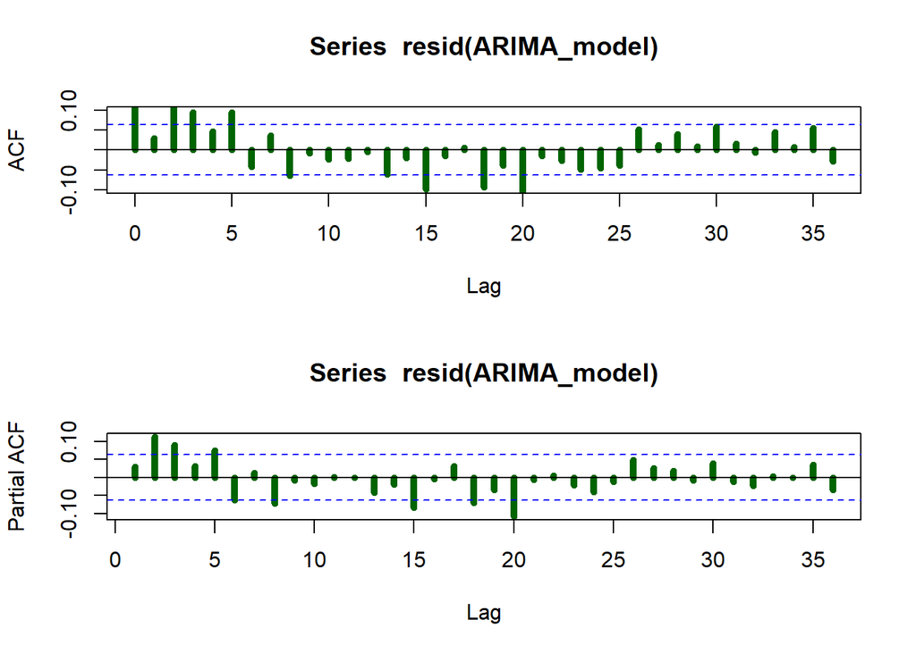

```r
plot_ACF_PACF_resids(arima111_second)
```

ACF and PACF plots shows that some lags are still significant

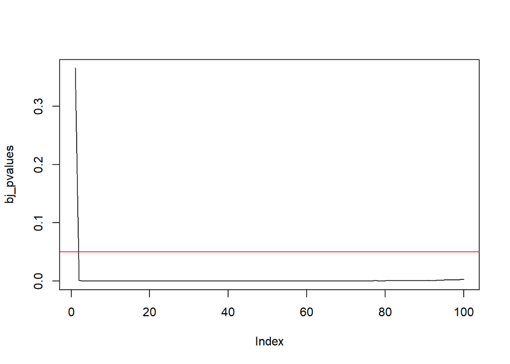

```r
bj_pvalues = c()
for(i in c(1:100)){
  bj = Box.test(resid(arima111_second), type = "Ljung-Box", lag = i)
  bj_pvalues = append(bj_pvalues,bj$p.value)
}
plot(bj_pvalues, type='l')
abline(h=0.05, col='red', type='l')
```

residuals are **not** white noise

### ARIMA(3,1,3)

```r
arima313_second <- Arima(chosen_ones$second, order = c(3, 1, 3))

coeftest(arima313_second)
```

```
##
## z test of coefficients:
##
##     Estimate Std. Error z value    Pr(>|z|)
## ar1 -0.69948    0.15625 -4.4766 0.000007586 ***
## ar2  0.43675    0.12264  3.5613   0.0003691 ***
## ar3  0.45500    0.16157  2.8160   0.0048620 **
## ma1  0.61295    0.17364  3.5299   0.0004156 ***
## ma2 -0.32711    0.12473 -2.6224   0.0087309 **
## ma3 -0.27047    0.18425 -1.4679   0.1421213
## ---
## Signif. codes:  0 '***' 0.001 '**' 0.01 '*' 0.05 '.' 0.1 ' ' 1
```

ma3 not significant

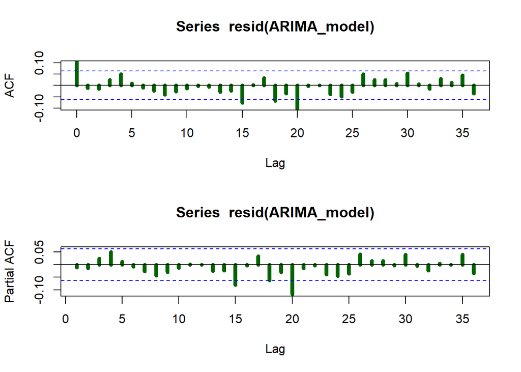

```r
plot_ACF_PACF_resids(arima313_second)
```

lags 15, 18, 20 are still significant

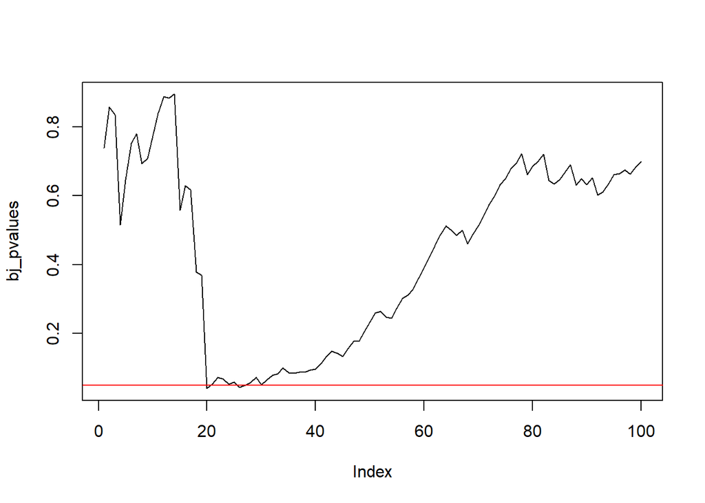

```r
bj_pvalues = c()
for(i in c(1:100)){
  bj = Box.test(resid(arima313_second), type = "Ljung-Box", lag = i)
  bj_pvalues = append(bj_pvalues,bj$p.value)
}
plot(bj_pvalues, type='l')
abline(h=0.05, col='red', type='l')
```

### ARIMA(15,1,3)

```r
arima1513_second <- Arima(chosen_ones$second, order = c(15, 1, 3))

coeftest(arima1513_second)
```

```
##
## z test of coefficients:
##
##         Estimate  Std. Error z value        Pr(>|z|)
## ar1  -0.45961418  0.12457586 -3.6894       0.0002248 ***
## ar2   0.29851379  0.12421851  2.4031       0.0162552 *
## ar3   0.86593217  0.14033367  6.1705 0.0000000006806 ***
## ar4   0.12694974  0.05360818  2.3681       0.0178795 *
## ar5  -0.02375220  0.05051925 -0.4702       0.6382398
## ar6  -0.08617609  0.04830743 -1.7839       0.0744384 .
## ar7  -0.07012616  0.04784225 -1.4658       0.1427085
## ar8  -0.10882218  0.04800295 -2.2670       0.0233909 *
## ar9  -0.01043293  0.04682220 -0.2228       0.8236754
## ar10  0.00091721  0.04684667  0.0196       0.9843792
## ar11  0.05723380  0.04685247  1.2216       0.2218684
## ar12  0.02730831  0.04640708  0.5885       0.5562293
## ar13 -0.03706947  0.03950027 -0.9385       0.3480074
## ar14 -0.03571369  0.03999728 -0.8929       0.3719091
## ar15 -0.07290561  0.03589335 -2.0312       0.0422374 *
## ma1   0.35617275  0.12195352  2.9206       0.0034940 **
## ma2  -0.19671314  0.11589693 -1.6973       0.0896379 .
## ma3  -0.72440935  0.13056441 -5.5483 0.0000000288476 ***
## ---
## Signif. codes:  0 '***' 0.001 '**' 0.01 '*' 0.05 '.' 0.1 ' ' 1
```

ar1, ar2, ar3, ar4, ar8, ar15, ma1, ma3 significant

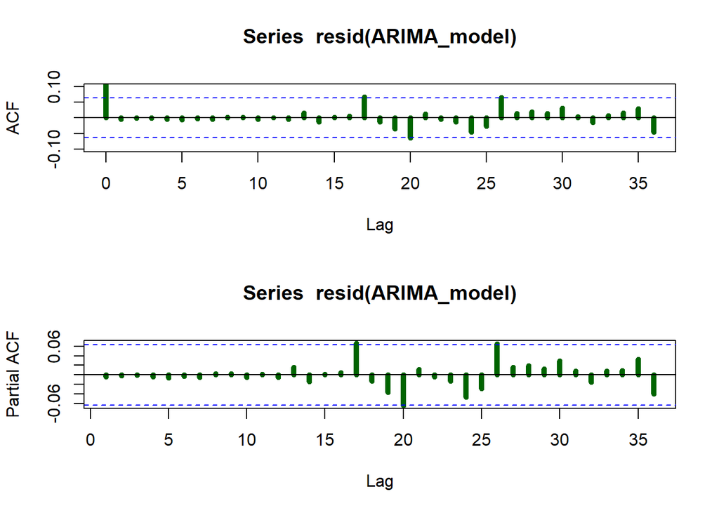

```r
plot_ACF_PACF_resids(arima1513_second)
```

lags 17, 20, 26 are still significant

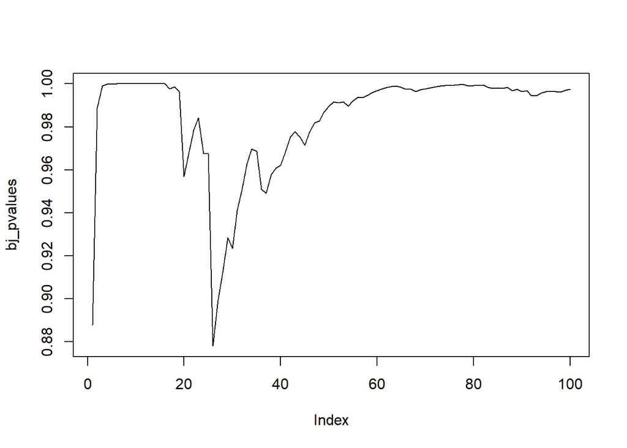

```r
bj_pvalues = c()
for(i in c(1:100)){
  bj = Box.test(resid(arima1513_second), type = "Ljung-Box", lag = i)
  bj_pvalues = append(bj_pvalues,bj$p.value)
}
plot(bj_pvalues, type='l')
abline(h=0.05, col='red', type='l')
```

residuals are white noise

### Checking previous models, but without insignificant variables

### ARIMA(3,1,3) without ma3 = ARIMA(3,1,2)

```r
arima312_second <- Arima(chosen_ones$second, order = c(3, 1, 2))

coeftest(arima312_second)
```

```
##
## z test of coefficients:
##
##      Estimate Std. Error z value         Pr(>|z|)
## ar1 -0.547622   0.142159 -3.8522        0.0001171 ***
## ar2  0.484456   0.132226  3.6638        0.0002485 ***
## ar3  0.212302   0.032435  6.5454 0.00000000005934 ***
## ma1  0.444043   0.144460  3.0738        0.0021134 **
## ma2 -0.377636   0.133596 -2.8267        0.0047030 **
## ---
## Signif. codes:  0 '***' 0.001 '**' 0.01 '*' 0.05 '.' 0.1 ' ' 1
```

everything significant

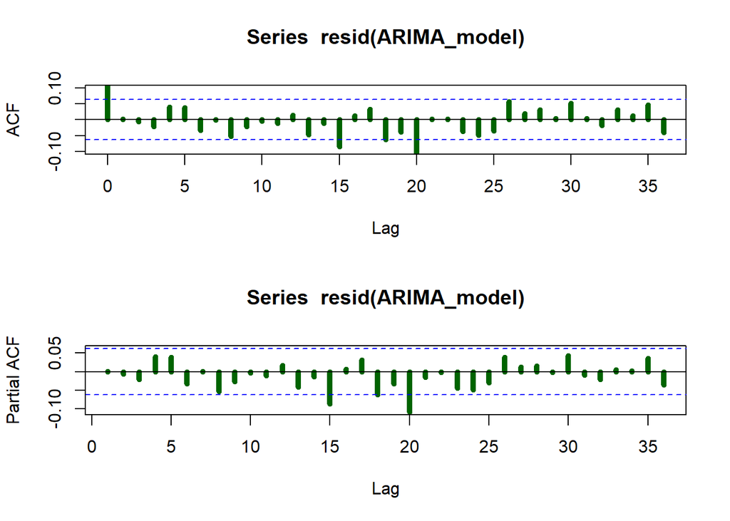

```r
plot_ACF_PACF_resids(arima312_second)
```

lags 15, 18, 20, 26 are still significant

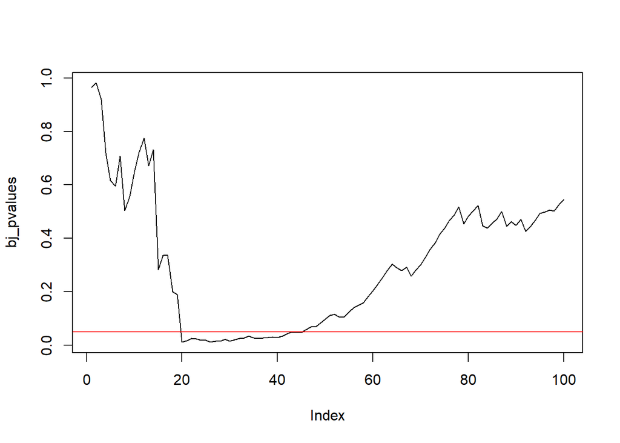

```r
bj_pvalues = c()
for(i in c(1:100)){
  bj = Box.test(resid(arima312_second), type = "Ljung-Box", lag = i)
  bj_pvalues = append(bj_pvalues,bj$p.value)
}
plot(bj_pvalues, type='l')
abline(h=0.05, col='red', type='l')
```

### ARIMA(15,1,3), but without insignificant variables

```r
arima1513_fixed_second <- Arima(chosen_ones$second,
                                order = c(15, 1, 3),
                                fixed = c(NA, NA, NA, NA, 0, 0, 0, NA, 0, 0, 0, 0, 0, 0, NA,
                                          NA, 0, NA))

coeftest(arima1513_fixed_second)
```

```
##
## z test of coefficients:
##
##       Estimate Std. Error z value Pr(>|z|)
## ar1  -0.202812   0.616514 -0.3290 0.742182
## ar2   0.137515   0.050793  2.7074 0.006782 **
## ar3   0.537305   0.267616  2.0077 0.044671 *
## ar4   0.074661   0.040647  1.8368 0.066241 .
## ar8  -0.085740   0.034029 -2.5196 0.011748 *
## ar15 -0.093163   0.030655 -3.0391 0.002373 **
## ma1   0.105182   0.626384  0.1679 0.866647
## ma3  -0.481680   0.189486 -2.5420 0.011021 *
## ---
## Signif. codes:  0 '***' 0.001 '**' 0.01 '*' 0.05 '.' 0.1 ' ' 1
```

ar1, ar4, ma1 not significant

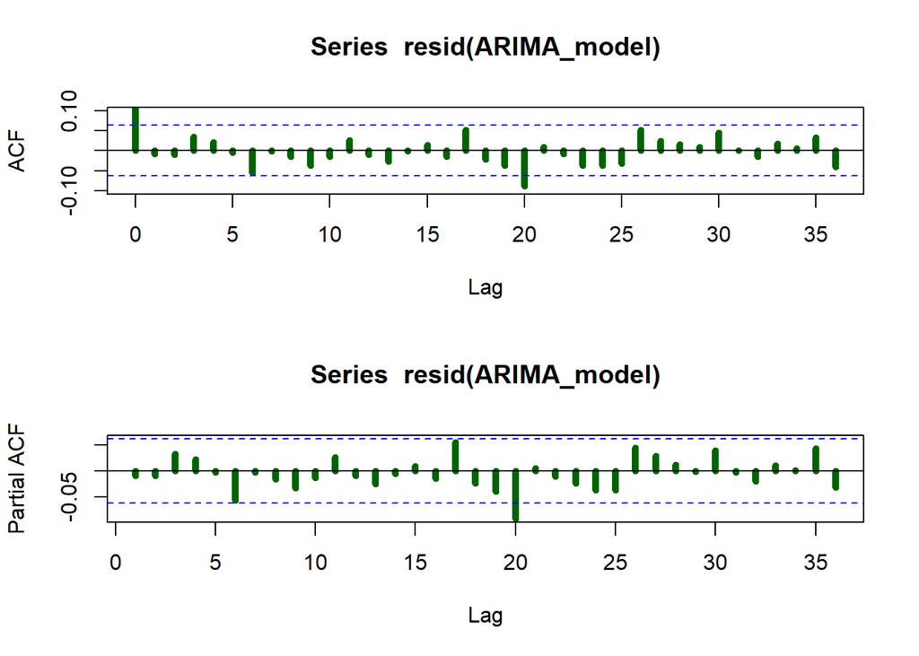

```r
plot_ACF_PACF_resids(arima1513_fixed_second)
```

lag 20 is still significant, lag 6 and 17 on line

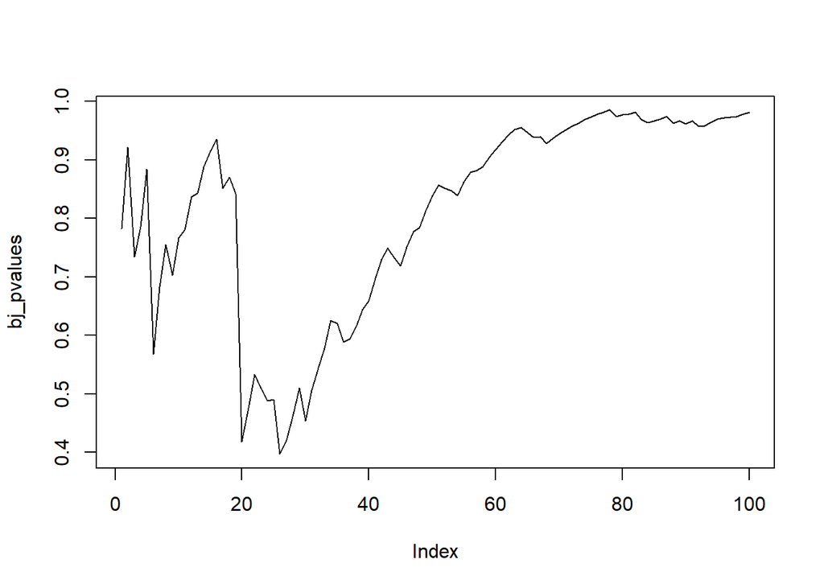

```r
bj_pvalues = c()
for(i in c(1:100)){
  bj = Box.test(resid(arima1513_fixed_second), type = "Ljung-Box", lag = i)
  bj_pvalues = append(bj_pvalues,bj$p.value)
}
plot(bj_pvalues, type='l')
abline(h=0.05, col='red', type='l')
```

residuals are white noise

### ARIMA(15,1,3) fixed, but without insignificant variables

```r
arima1513_fixed2_second <- Arima(chosen_ones$second,
                                order = c(15, 1, 3),
                                fixed = c(0, NA, NA, 0, 0, 0, 0, NA, 0, 0, 0, 0, 0, 0, NA,
                                          0, 0, NA))

coeftest(arima1513_fixed2_second)
```

```
##
## z test of coefficients:
##
##       Estimate Std. Error z value     Pr(>|z|)
## ar2   0.153783   0.029831  5.1551 0.0000002535 ***
## ar3   0.490485   0.142821  3.4343    0.0005942 ***
## ar8  -0.090159   0.031521 -2.8603    0.0042330 **
## ar15 -0.092459   0.028295 -3.2677    0.0010841 **
## ma3  -0.467705   0.157036 -2.9783    0.0028982 **
## ---
## Signif. codes:  0 '***' 0.001 '**' 0.01 '*' 0.05 '.' 0.1 ' ' 1
```

everything significant

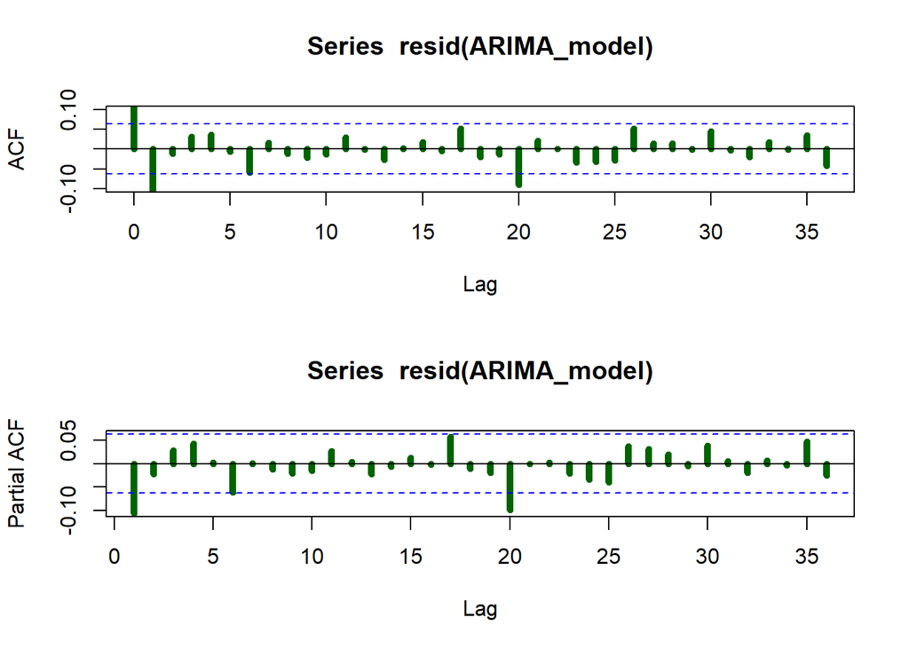

```r
plot_ACF_PACF_resids(arima1513_fixed2_second)
```

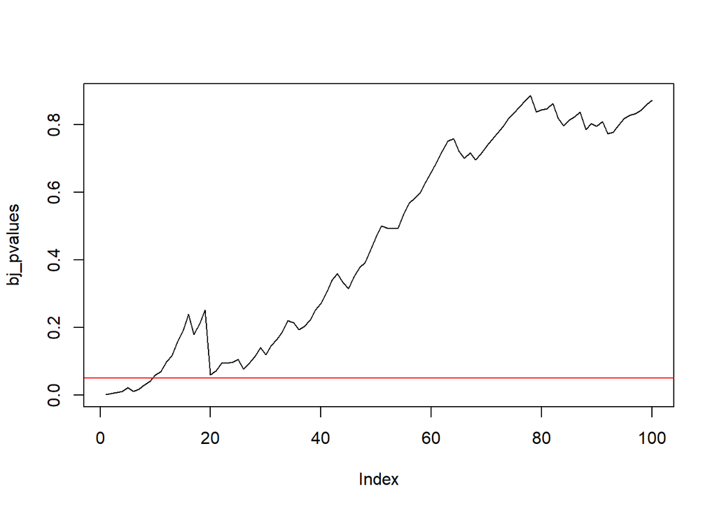

```r
bj_pvalues = c()
for(i in c(1:100)){
  bj = Box.test(resid(arima1513_fixed2_second), type = "Ljung-Box", lag = i)
  bj_pvalues = append(bj_pvalues,bj$p.value)
}
plot(bj_pvalues, type='l')
abline(h=0.05, col='red', type='l')
```

# 4-2 INFORMATION CRITERIAS

```r
AIC(arima111_second, arima313_second, arima1513_second, arima1513_fixed_second, arima1513_fixed2_second)
```

```
##                         df      AIC
## arima111_second          3 3515.571
## arima313_second          7 3493.607
## arima1513_second        19 3495.411
## arima1513_fixed_second   9 3486.036
## arima1513_fixed2_second  6 3490.533
```

```r
BIC(arima111_second, arima313_second, arima1513_second, arima1513_fixed_second, arima1513_fixed2_second)
```

```
##                         df      BIC
## arima111_second          3 3530.199
## arima313_second          7 3527.741
## arima1513_second        19 3588.060
## arima1513_fixed_second   9 3529.923
## arima1513_fixed2_second  6 3519.790
```

### choosing 3 with the lowest AIC - (arima1513_fixed_second, arima1513_fixed2_second, arima313_second)

```r
arima1513_fixed_second_forecast <- forecast(arima1513_fixed_second, h=30)
arima1513_fixed_second_forecast
```

```
##      Point Forecast    Lo 80    Hi 80    Lo 95    Hi 95
##  971       41.50140 39.63761 43.36519 38.65098 44.35182
##  972       41.35809 38.84766 43.86853 37.51872 45.19747
##  973       41.28646 38.09224 44.48068 36.40133 46.17160
##  974       41.24033 37.47470 45.00595 35.48130 46.99936
##  975       41.00214 36.70408 45.30019 34.42883 47.57544
##  976       41.03793 36.20826 45.86761 33.65158 48.42429
##  977       40.90326 35.58812 46.21840 32.77446 49.03206
##  978       41.06116 35.27878 46.84355 32.21777 49.90456
##  979       41.07998 34.89892 47.26104 31.62687 50.53310
##  980       41.17188 34.59576 47.74800 31.11458 51.22918
##  981       41.33849 34.39553 48.28145 30.72015 51.95683
##  982       41.33414 34.05350 48.61479 30.19936 52.46893
##  983       41.38170 33.77144 48.99196 29.74281 53.02059
##  984       41.34026 33.42132 49.25920 29.22928 53.45123
```

[output cut: 16 more lines]

```r
arima1513_fixed_second_forecast_data <- data.frame(f_mean  = as.numeric(arima1513_fixed_second_forecast$mean),
                                           f_lower = as.numeric(arima1513_fixed_second_forecast$lower[, 2]),
                                           f_upper = as.numeric(arima1513_fixed_second_forecast$upper[, 2]))

arima1513_fixed_second_forecast_data_xts <- xts(arima1513_fixed_second_forecast_data, order.by = data_test$X)
```

```r
arima1513_fixed2_second_forecast <- forecast(arima1513_fixed2_second, h=30)
arima1513_fixed2_second_forecast
```

```
##      Point Forecast    Lo 80    Hi 80    Lo 95    Hi 95
##  971       41.29195 39.42095 43.16294 38.43051 44.15339
##  972       41.12899 38.48300 43.77497 37.08230 45.17567
##  973       41.04265 37.62778 44.45752 35.82006 46.26524
##  974       40.99733 36.93442 45.06024 34.78365 47.21101
##  975       40.72716 36.08498 45.36935 33.62755 47.82678
##  976       40.71796 35.49516 45.94076 32.73037 48.70554
##  977       40.58337 34.82674 46.34001 31.77937 49.38738
##  978       40.71331 34.45096 46.97565 31.13588 50.29074
##  979       40.77322 34.07621 47.47024 30.53102 51.01542
##  980       40.87229 33.76030 47.98428 29.99544 51.74914
##  981       41.05398 33.55575 48.55222 29.58642 52.52154
##  982       41.09371 33.24190 48.94552 29.08540 53.10202
##  983       41.14752 32.95646 49.33858 28.62037 53.67466
##  984       41.12000 32.61119 49.62882 28.10690 54.13311
```

[output cut: 16 more lines]

```r
arima1513_fixed2_second_forecast_data <- data.frame(f_mean  = as.numeric(arima1513_fixed2_second_forecast$mean),
                                     f_lower = as.numeric(arima1513_fixed2_second_forecast$lower[, 2]),
                                     f_upper = as.numeric(arima1513_fixed2_second_forecast$upper[, 2]))

arima1513_fixed2_second_forecast_data_xts <- xts(arima1513_fixed2_second_forecast_data, order.by = data_test$X)
```

```r
arima313_second_forecast <- forecast(arima313_second, h=30)
arima313_second_forecast
```

```
##      Point Forecast    Lo 80    Hi 80    Lo 95    Hi 95
##  971       41.61777 39.74459 43.49095 38.75298 44.48255
##  972       41.36187 38.82481 43.89892 37.48177 45.24196
##  973       41.33638 38.08724 44.58553 36.36725 46.30552
##  974       41.39971 37.54087 45.25855 35.49812 47.30130
##  975       41.22785 36.82937 45.62633 34.50096 47.95474
##  976       41.36412 36.41982 46.30843 33.80246 48.92579
##  977       41.22256 35.81432 46.63079 32.95138 49.49374
##  978       41.30290 35.41972 47.18608 32.30535 50.30045
##  979       41.24688 34.94211 47.55165 31.60457 50.88919
##  980       41.25674 34.53695 47.97654 30.97971 51.53378
##  981       41.26193 34.15312 48.37074 30.38994 52.13392
##  982       41.23712 33.75732 48.71692 29.79775 52.67649
##  983       41.26123 33.42229 49.10017 29.27260 53.24986
##  984       41.23589 33.05723 49.41455 28.72771 53.74407
```

[output cut: 16 more lines]

```r
arima313_second_forecast_data <- data.frame(f_mean  = as.numeric(arima313_second_forecast$mean),
                                          f_lower = as.numeric(arima313_second_forecast$lower[, 2]),
                                          f_upper = as.numeric(arima313_second_forecast$upper[, 2]))

arima313_second_forecast_data_xts <- xts(arima313_second_forecast_data, order.by = data_test$X)
```

# VISUALIZATION OF THE SECOND TIME SERIES

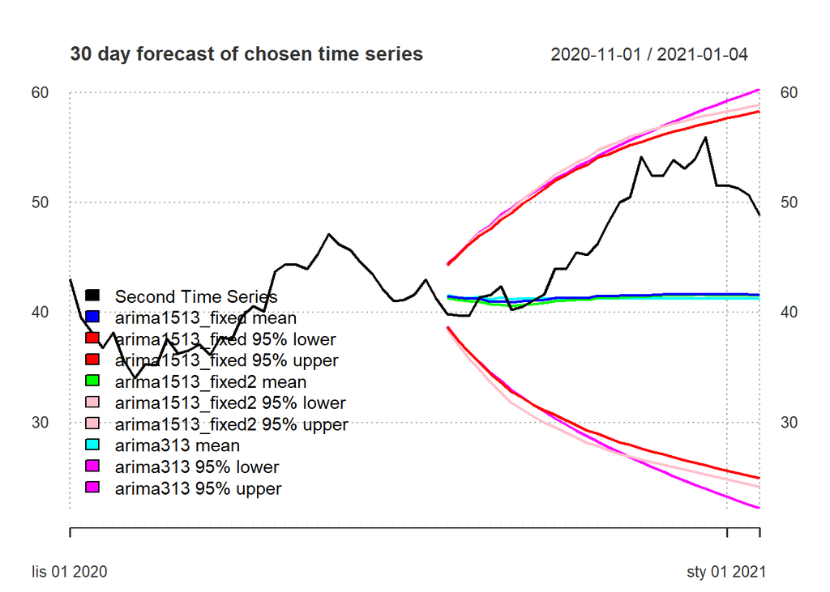

```r
data_all_second_xts <- rbind(data_train_xts[,9], data_test_xts[,9])
names(data_all_second_xts) <- "second"

ARIMA_forecasts_second <- merge(data_all_second_xts,
                               arima1513_fixed_second_forecast_data_xts,
                               arima1513_fixed2_second_forecast_data_xts,
                               arima313_second_forecast_data_xts)
names(ARIMA_forecasts_second) <- c("Second Time Series", "arima1513_fixed mean", "arima1513_fixed 95% lower", "arima1513_fixed 95% upper", "arima1513_fixed2 mean", "arima1513_fixed2 95% lower", "arima1513_fixed2 95% upper", "arima313 mean", "arima313 95% lower", "arima313 95% upper")

plot(ARIMA_forecasts_second["2020-11/",],
     major.ticks = "years",
     grid.ticks.on = "years",
     grid.ticks.lty = 3,
     main = "30 day forecast of chosen time series",
     col = c("black", "blue", "red", "red", "green", "pink", "pink", "cyan", "magenta", "magenta"),
     legend.loc = "bottomleft")
```

# ECM and VECM

```r
ecm_model <- lm(diff_first ~ diff_second + lag_resid_coint, data = chosen_ones)
```

delete the intercept

```r
ecm_model <- lm(diff_first ~ diff_second + lag_resid_coint -1, data = chosen_ones)

summary(ecm_model)
```

```
##
## Call:
## lm(formula = diff_first ~ diff_second + lag_resid_coint - 1,
##     data = chosen_ones)
##
## Residuals:
##     Min      1Q  Median      3Q     Max
## -3.7687 -0.7700  0.0304  0.8620  4.0564
##
## Coefficients:
##                 Estimate Std. Error t value Pr(>|t|)
## diff_second     -0.03568    0.02798  -1.275    0.203
## lag_resid_coint -0.55365    0.02999 -18.463   <2e-16 ***
## ---
## Signif. codes:  0 '***' 0.001 '**' 0.01 '*' 0.05 '.' 0.1 ' ' 1
##
## Residual standard error: 1.249 on 967 degrees of freedom
##   (1 obserwacja została skasowana z uwagi na braki w niej zawarte)
## Multiple R-squared:   0.27,  Adjusted R-squared:  0.2685
## F-statistic: 178.8 on 2 and 967 DF,  p-value: < 2.2e-16
```

diff_second is not statistically significant, but lets leave it

The parameter -0.03568 describes a short term relationship between `first` and `second`, so if `second` increases by 1 then the `first` in the *short run* will decrease by 0.03568.

The *long run* relationship is described by the parameter 0.271123 from the cointegrating relationship: so if `first` increases by 1 in the LONG RUN `second` will increase by 0.271123.

The value of -0.55365 is the estimate of the *adjustment coefficient*. As expected, its sign is negative and this value means that about 55.37% of the unexpected error (increase in gap) will be corrected in the next period, so any unexpected deviation should be corrected finally on average within about 1.8 periods.

# GRANGER CAUSALITY TEST

```r
grangertest(first ~ second,
            data = chosen_ones,
            order = 3)
```

```
## Granger causality test
##
## Model 1: first ~ Lags(first, 1:3) + Lags(second, 1:3)
## Model 2: first ~ Lags(first, 1:3)
##   Res.Df Df      F    Pr(>F)
## 1    960
## 2    963 -3 68.729 < 2.2e-16 ***
## ---
## Signif. codes:  0 '***' 0.001 '**' 0.01 '*' 0.05 '.' 0.1 ' ' 1
```

second causes first (we rejected null hypothesis about no causality)

```r
grangertest(second ~ first,
            data = chosen_ones,
            order = 3)
```

```
## Granger causality test
##
## Model 1: second ~ Lags(second, 1:3) + Lags(first, 1:3)
## Model 2: second ~ Lags(second, 1:3)
##   Res.Df Df      F    Pr(>F)
## 1    960
## 2    963 -3 279.61 < 2.2e-16 ***
## ---
## Signif. codes:  0 '***' 0.001 '**' 0.01 '*' 0.05 '.' 0.1 ' ' 1
```

first causes second (we rejected null hypothesis about no causality)

```r
for(i in 1:5){
  print(i)
  print("first ~ second")
  print(grangertest(first ~ second,
                    data = chosen_ones,
                    order = i))
  print(i)
  print("second ~ first")
  print(grangertest(second ~ first,
              data = chosen_ones,
              order = i))
}
```

```
## [1] 1
## [1] "first ~ second"
## Granger causality test
##
## Model 1: first ~ Lags(first, 1:1) + Lags(second, 1:1)
## Model 2: first ~ Lags(first, 1:1)
##   Res.Df Df      F    Pr(>F)
## 1    966
## 2    967 -1 331.28 < 2.2e-16 ***
## ---
## Signif. codes:  0 '***' 0.001 '**' 0.01 '*' 0.05 '.' 0.1 ' ' 1
## [1] 1
## [1] "second ~ first"
## Granger causality test
##
## Model 1: second ~ Lags(second, 1:1) + Lags(first, 1:1)
## Model 2: second ~ Lags(second, 1:1)
##   Res.Df Df      F    Pr(>F)
## 1    966
## 2    967 -1 83.975 < 2.2e-16 ***
## ---
## Signif. codes:  0 '***' 0.001 '**' 0.01 '*' 0.05 '.' 0.1 ' ' 1
## [1] 2
## [1] "first ~ second"
## Granger causality test
##
## Model 1: first ~ Lags(first, 1:2) + Lags(second, 1:2)
## Model 2: first ~ Lags(first, 1:2)
##   Res.Df Df      F    Pr(>F)
## 1    963
## 2    965 -2 58.985 < 2.2e-16 ***
## ---
## Signif. codes:  0 '***' 0.001 '**' 0.01 '*' 0.05 '.' 0.1 ' ' 1
## [1] 2
## [1] "second ~ first"
## Granger causality test
##
## Model 1: second ~ Lags(second, 1:2) + Lags(first, 1:2)
## Model 2: second ~ Lags(second, 1:2)
##   Res.Df Df      F    Pr(>F)
```

[output cut: 55 more lines]

```
## 1    954
## 2    959 -5 3.7227 0.002419 **
## ---
## Signif. codes:  0 '***' 0.001 '**' 0.01 '*' 0.05 '.' 0.1 ' ' 1
## [1] 5
## [1] "second ~ first"
## Granger causality test
##
## Model 1: second ~ Lags(second, 1:5) + Lags(first, 1:5)
## Model 2: second ~ Lags(second, 1:5)
##   Res.Df Df      F    Pr(>F)
## 1    954
## 2    959 -5 207.67 < 2.2e-16 ***
## ---
## Signif. codes:  0 '***' 0.001 '**' 0.01 '*' 0.05 '.' 0.1 ' ' 1
```

**Conclusion** - we have bi-directional feedback in all cases

# VAR MODELS

### Select VAR model with proper lag lenght

```r
VARselect(chosen_ones[,1:2], lag.max = 10) %>%
  .$criteria %>%
  t() %>%
  as_tibble() %>%
  mutate(nLags = 1:nrow(.)) %>%
  kbl(digits = 3) %>%
  kable_classic("striped", full_width = F)
```

| AIC(n) | HQ(n) | SC(n) | FPE(n) | nLags |
| --- | --- | --- | --- | --- |
| 1.171 | 1.183 | 1.202 | 3.226 | 1 |
| 1.057 | 1.076 | 1.107 | 2.877 | 2 |
| 0.429 | 0.456 | 0.500 | 1.536 | 3 |
| 0.337 | 0.372 | 0.428 | 1.401 | 4 |
| 0.145 | 0.188 | 0.257 | 1.156 | 5 |
| 0.107 | 0.158 | 0.239 | 1.113 | 6 |
| 0.108 | 0.166 | 0.260 | 1.114 | 7 |
| 0.109 | 0.175 | 0.282 | 1.115 | 8 |
| 0.111 | 0.185 | 0.304 | 1.118 | 9 |
| 0.118 | 0.199 | 0.331 | 1.125 | 10 |

6 lags are the best according to all information criterias

### Check IC with seasonal VAR

```r
VARselect(chosen_ones[,1:2], lag.max = 10, season = 31) %>%
  .$criteria %>%
  t() %>%
  as_tibble() %>%
  mutate(nLags = 1:nrow(.)) %>%
  kbl(digits = 3) %>%
  kable_classic("striped", full_width = F)
```

| AIC(n) | HQ(n) | SC(n) | FPE(n) | nLags |
| --- | --- | --- | --- | --- |
| 1.238 | 1.366 | 1.573 | 3.450 | 1 |
| 1.121 | 1.256 | 1.476 | 3.068 | 2 |
| 0.498 | 0.641 | 0.873 | 1.646 | 3 |
| 0.410 | 0.561 | 0.806 | 1.507 | 4 |
| 0.213 | 0.371 | 0.629 | 1.237 | 5 |
| 0.176 | 0.342 | 0.612 | 1.192 | 6 |
| 0.177 | 0.351 | 0.633 | 1.194 | 7 |
| 0.179 | 0.360 | 0.655 | 1.196 | 8 |
| 0.180 | 0.369 | 0.677 | 1.197 | 9 |
| 0.186 | 0.383 | 0.703 | 1.204 | 10 |

With ACF and PACF we showed that there is no seasonality detected

### Check season = 31, 30, 7

```r
VAR_model_6_lags <- VAR(chosen_ones[,1:2],
                        p = 6,
                        season = 31)

summary(VAR_model_6_lags)
```

```
##
## VAR Estimation Results:
## =========================
## Endogenous variables: first, second
## Deterministic variables: const
## Sample size: 964
## Log Likelihood: -2734.013
## Roots of the characteristic polynomial:
## 0.9949 0.8975 0.8975 0.8476 0.8476 0.805 0.805 0.6675 0.6675 0.5844 0.2978 0.2978
## Call:
## VAR(y = chosen_ones[, 1:2], p = 6, season = 31L)
##
##
## Estimation results for equation first:
## ======================================
## first = first.l1 + second.l1 + first.l2 + second.l2 + first.l3 + second.l3 + first.l4 + second.l4 + first.l5 + second.l5 + first.l6 + second.l6 + const + sd1 + sd2 + sd3 + sd4 + sd5 + sd6 + sd7 + sd8 + sd9 + sd10 + sd11 + sd12 + sd13 + sd14 + sd15 + sd16 + sd17 + sd18 + sd19 + sd20 + sd21 + sd22 …
##
##            Estimate Std. Error t value Pr(>|t|)
## first.l1   0.412069   0.032459  12.695  < 2e-16 ***
## second.l1  0.012143   0.033342   0.364  0.71581
## first.l2   0.351663   0.031991  10.992  < 2e-16 ***
## second.l2 -0.018366   0.039415  -0.466  0.64135
## first.l3  -0.276530   0.033872  -8.164 1.06e-15 ***
## second.l3  0.008696   0.039941   0.218  0.82768
## first.l4   0.137860   0.042971   3.208  0.00138 **
## second.l4 -0.047817   0.035481  -1.348  0.17809
## first.l5   0.550785   0.041066  13.412  < 2e-16 ***
## second.l5  0.006523   0.033316   0.196  0.84482
## first.l6  -0.217983   0.041872  -5.206 2.38e-07 ***
## second.l6  0.030358   0.025769   1.178  0.23906
## const      6.309802   8.682215   0.727  0.46756
## sd1        0.436917   0.263223   1.660  0.09728 .
## sd2        0.389225   0.263523   1.477  0.14002
## sd3        0.013090   0.263582   0.050  0.96040
## sd4        0.139813   0.262998   0.532  0.59512
## sd5        0.324158   0.263200   1.232  0.21841
## sd6        0.288678   0.263868   1.094  0.27423
## sd7        0.341875   0.262072   1.305  0.19239
## sd8        0.132630   0.261898   0.506  0.61268
## sd9        0.153897   0.261664   0.588  0.55658
```

[output cut: 82 more lines]

```
## Residual standard error: 1.012 on 921 degrees of freedom
## Multiple R-Squared: 0.9977,  Adjusted R-squared: 0.9976
## F-statistic:  9549 on 42 and 921 DF,  p-value: < 2.2e-16
##
##
##
## Covariance matrix of residuals:
##            first    second
## first   1.066785 -0.006213
## second -0.006213  1.023390
##
## Correlation matrix of residuals:
##            first    second
## first   1.000000 -0.005947
## second -0.005947  1.000000
```

only sd10 in first is on the line of significance

```r
VAR_model_6_lags <- VAR(chosen_ones[,1:2],
                        p = 6,
                        season = 30)

summary(VAR_model_6_lags)
```

```
##
## VAR Estimation Results:
## =========================
## Endogenous variables: first, second
## Deterministic variables: const
## Sample size: 964
## Log Likelihood: -2734.264
## Roots of the characteristic polynomial:
## 0.9948 0.898 0.898 0.8485 0.8485 0.8015 0.8015 0.6538 0.6538 0.5733 0.2823 0.2823
## Call:
## VAR(y = chosen_ones[, 1:2], p = 6, season = 30L)
##
##
## Estimation results for equation first:
## ======================================
## first = first.l1 + second.l1 + first.l2 + second.l2 + first.l3 + second.l3 + first.l4 + second.l4 + first.l5 + second.l5 + first.l6 + second.l6 + const + sd1 + sd2 + sd3 + sd4 + sd5 + sd6 + sd7 + sd8 + sd9 + sd10 + sd11 + sd12 + sd13 + sd14 + sd15 + sd16 + sd17 + sd18 + sd19 + sd20 + sd21 + sd22 …
##
##             Estimate Std. Error t value Pr(>|t|)
## first.l1   0.4152249  0.0323767  12.825  < 2e-16 ***
## second.l1  0.0004024  0.0333528   0.012   0.9904
## first.l2   0.3449477  0.0320064  10.777  < 2e-16 ***
## second.l2 -0.0126853  0.0394666  -0.321   0.7480
## first.l3  -0.2727069  0.0338272  -8.062 2.32e-15 ***
## second.l3  0.0086819  0.0399932   0.217   0.8282
## first.l4   0.1359678  0.0431931   3.148   0.0017 **
## second.l4 -0.0457775  0.0353938  -1.293   0.1962
## first.l5   0.5474513  0.0412618  13.268  < 2e-16 ***
## second.l5  0.0034201  0.0333421   0.103   0.9183
## first.l6  -0.2316499  0.0418268  -5.538 3.98e-08 ***
## second.l6  0.0323465  0.0257567   1.256   0.2095
## const      9.1479257  8.7423020   1.046   0.2957
## sd1       -0.0449304  0.2594271  -0.173   0.8625
## sd2        0.0699766  0.2600265   0.269   0.7879
## sd3       -0.3265467  0.2591226  -1.260   0.2079
## sd4       -0.3759164  0.2592564  -1.450   0.1474
## sd5       -0.2277308  0.2598218  -0.876   0.3810
## sd6       -0.0106064  0.2598375  -0.041   0.9674
## sd7       -0.0686757  0.2584044  -0.266   0.7905
## sd8       -0.2632735  0.2579693  -1.021   0.3077
## sd9       -0.0440450  0.2579175  -0.171   0.8644
```

[output cut: 80 more lines]

```
## Residual standard error: 1.011 on 922 degrees of freedom
## Multiple R-Squared: 0.9977,  Adjusted R-squared: 0.9976
## F-statistic:  9791 on 41 and 922 DF,  p-value: < 2.2e-16
##
##
##
## Covariance matrix of residuals:
##            first    second
## first   1.065987 -0.004382
## second -0.004382  1.022450
##
## Correlation matrix of residuals:
##            first    second
## first   1.000000 -0.004198
## second -0.004198  1.000000
```

only sd12 in first is on the line of significance

```r
VAR_model_6_lags <- VAR(chosen_ones[,1:2],
                        p = 6,
                        season = 7)

summary(VAR_model_6_lags)
```

```
##
## VAR Estimation Results:
## =========================
## Endogenous variables: first, second
## Deterministic variables: const
## Sample size: 964
## Log Likelihood: -2751.952
## Roots of the characteristic polynomial:
## 0.9948 0.8947 0.8947 0.8489 0.8489 0.8087 0.8087 0.6477 0.6477 0.5735 0.2775 0.2775
## Call:
## VAR(y = chosen_ones[, 1:2], p = 6, season = 7L)
##
##
## Estimation results for equation first:
## ======================================
## first = first.l1 + second.l1 + first.l2 + second.l2 + first.l3 + second.l3 + first.l4 + second.l4 + first.l5 + second.l5 + first.l6 + second.l6 + const + sd1 + sd2 + sd3 + sd4 + sd5 + sd6
##
##            Estimate Std. Error t value           Pr(>|t|)
## first.l1   0.414621   0.032008  12.954            < 2e-16 ***
## second.l1  0.006260   0.033089   0.189           0.849983
## first.l2   0.344559   0.031740  10.856            < 2e-16 ***
## second.l2 -0.018279   0.039177  -0.467           0.640920
## first.l3  -0.270575   0.033522  -8.071 0.0000000000000021 ***
## second.l3  0.014484   0.039717   0.365           0.715436
## first.l4   0.144997   0.042751   3.392           0.000723 ***
## second.l4 -0.042847   0.035239  -1.216           0.224330
## first.l5   0.541422   0.040901  13.237            < 2e-16 ***
## second.l5 -0.004683   0.033106  -0.141           0.887545
## first.l6  -0.224201   0.041386  -5.417 0.0000000768088114 ***
## second.l6  0.034696   0.025542   1.358           0.174660
## const      7.380634   8.584519   0.860           0.390139
## sd1        0.084225   0.125343   0.672           0.501775
## sd2        0.043972   0.125016   0.352           0.725121
## sd3        0.259196   0.124919   2.075           0.038265 *
## sd4        0.064682   0.125404   0.516           0.606122
## sd5        0.111747   0.125508   0.890           0.373500
## sd6        0.100328   0.125910   0.797           0.425756
## ---
## Signif. codes:  0 '***' 0.001 '**' 0.01 '*' 0.05 '.' 0.1 ' ' 1
##
```

[output cut: 34 more lines]

```
## Residual standard error: 1.005 on 945 degrees of freedom
## Multiple R-Squared: 0.9977,  Adjusted R-squared: 0.9976
## F-statistic: 2.256e+04 on 18 and 945 DF,  p-value: < 2.2e-16
##
##
##
## Covariance matrix of residuals:
##            first    second
## first   1.064716 -0.001412
## second -0.001412  1.010855
##
## Correlation matrix of residuals:
##            first    second
## first   1.000000 -0.001361
## second -0.001361  1.000000
```

only sd3 in first is statistically significant

```r
VAR_model_6_lags <- VAR(chosen_ones[,1:2],
                        p = 6)

summary(VAR_model_6_lags)
```

```
##
## VAR Estimation Results:
## =========================
## Endogenous variables: first, second
## Deterministic variables: const
## Sample size: 964
## Log Likelihood: -2760.828
## Roots of the characteristic polynomial:
## 0.9948 0.8971 0.8971 0.8491 0.8491 0.8082 0.8082 0.6518 0.6518 0.5721 0.2678 0.2678
## Call:
## VAR(y = chosen_ones[, 1:2], p = 6)
##
##
## Estimation results for equation first:
## ======================================
## first = first.l1 + second.l1 + first.l2 + second.l2 + first.l3 + second.l3 + first.l4 + second.l4 + first.l5 + second.l5 + first.l6 + second.l6 + const
##
##             Estimate Std. Error t value Pr(>|t|)
## first.l1   0.4122892  0.0319048  12.923  < 2e-16 ***
## second.l1  0.0048652  0.0328771   0.148 0.882389
## first.l2   0.3485211  0.0315145  11.059  < 2e-16 ***
## second.l2 -0.0141249  0.0389316  -0.363 0.716825
## first.l3  -0.2726954  0.0333280  -8.182 8.89e-16 ***
## second.l3  0.0124271  0.0394245   0.315 0.752669
## first.l4   0.1414226  0.0424945   3.328 0.000908 ***
## second.l4 -0.0456338  0.0349464  -1.306 0.191929
## first.l5   0.5472057  0.0406312  13.468  < 2e-16 ***
## second.l5 -0.0006806  0.0328653  -0.021 0.983482
## first.l6  -0.2261975  0.0412329  -5.486 5.28e-08 ***
## second.l6  0.0327048  0.0253728   1.289 0.197721
## const      7.4228439  8.5541285   0.868 0.385750
## ---
## Signif. codes:  0 '***' 0.001 '**' 0.01 '*' 0.05 '.' 0.1 ' ' 1
##
##
## Residual standard error: 1.031 on 951 degrees of freedom
## Multiple R-Squared: 0.9685,  Adjusted R-squared: 0.9681
## F-statistic:  2437 on 12 and 951 DF,  p-value: < 2.2e-16
##
##
```

[output cut: 22 more lines]

```
## Residual standard error: 1.009 on 951 degrees of freedom
## Multiple R-Squared: 0.9976,  Adjusted R-squared: 0.9976
## F-statistic: 3.361e+04 on 12 and 951 DF,  p-value: < 2.2e-16
##
##
##
## Covariance matrix of residuals:
##            first    second
## first   1.063698 -0.005516
## second -0.005516  1.017690
##
## Correlation matrix of residuals:
##            first    second
## first   1.000000 -0.005301
## second -0.005301  1.000000
```

Some variables are not significant, but in general all lag orders have some significant part

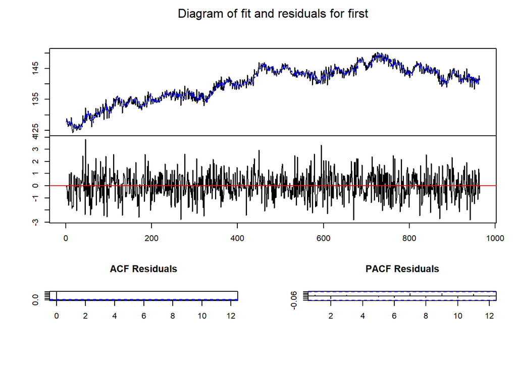

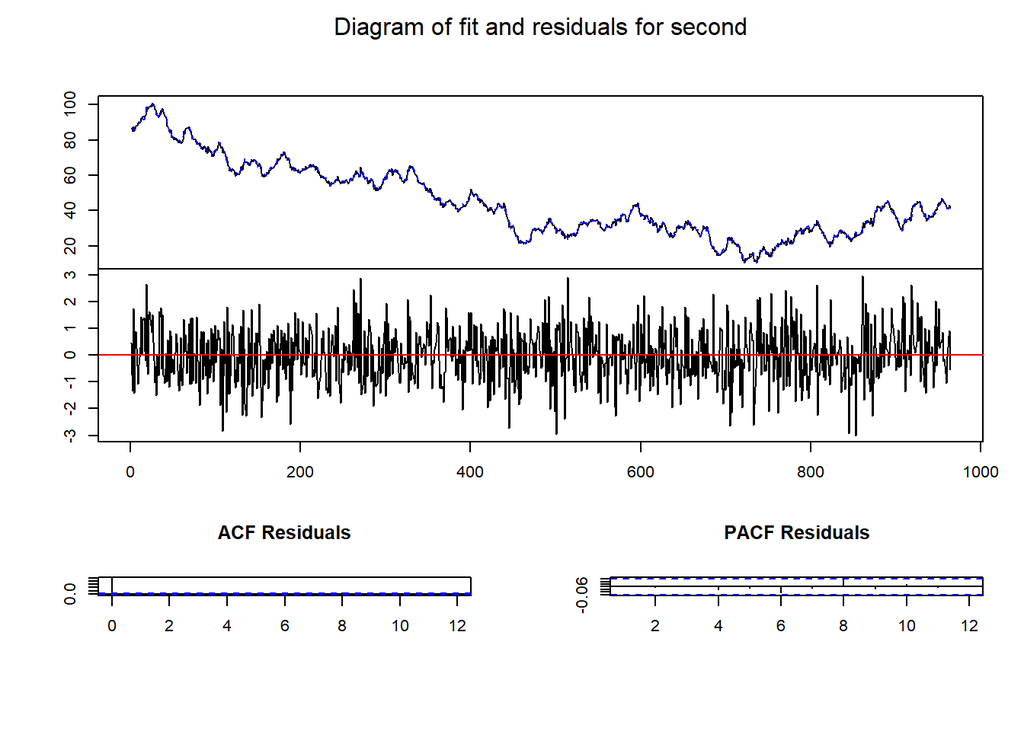

```r
plot(VAR_model_6_lags)
```

ACF and PACF for first looks good, but for second both ACF and PACF have lag 8 on the line so lets make a model with 8 lags

```r
VAR_model_8_lags <- VAR(chosen_ones[,1:2],
                        p = 8)

summary(VAR_model_8_lags)
```

```
##
## VAR Estimation Results:
## =========================
## Endogenous variables: first, second
## Deterministic variables: const
## Sample size: 962
## Log Likelihood: -2749.674
## Roots of the characteristic polynomial:
## 0.9949 0.9174 0.9174 0.8298 0.8298 0.8021 0.8021 0.6338 0.6338 0.6097 0.6097 0.5823 0.558 0.4282 0.3615 0.3615
## Call:
## VAR(y = chosen_ones[, 1:2], p = 8)
##
##
## Estimation results for equation first:
## ======================================
## first = first.l1 + second.l1 + first.l2 + second.l2 + first.l3 + second.l3 + first.l4 + second.l4 + first.l5 + second.l5 + first.l6 + second.l6 + first.l7 + second.l7 + first.l8 + second.l8 + const
##
##             Estimate Std. Error t value        Pr(>|t|)
## first.l1   0.4317431  0.0324449  13.307         < 2e-16 ***
## second.l1 -0.0069119  0.0330973  -0.209        0.834622
## first.l2   0.2995580  0.0351799   8.515         < 2e-16 ***
## second.l2  0.0020061  0.0398426   0.050        0.959853
## first.l3  -0.2478416  0.0360141  -6.882 0.0000000000108 ***
## second.l3  0.0026499  0.0402196   0.066        0.947482
## first.l4   0.1576745  0.0439169   3.590        0.000347 ***
## second.l4  0.0002069  0.0398929   0.005        0.995862
## first.l5   0.5174329  0.0441464  11.721         < 2e-16 ***
## second.l5 -0.0641490  0.0398598  -1.609        0.107870
## first.l6  -0.2400826  0.0459453  -5.225 0.0000002138639 ***
## second.l6  0.0516271  0.0354554   1.456        0.145693
## first.l7   0.1196800  0.0453064   2.642        0.008389 **
## second.l7  0.0185559  0.0332589   0.558        0.577028
## first.l8  -0.0908252  0.0422191  -2.151        0.031707 *
## second.l8 -0.0153414  0.0253561  -0.605        0.545299
## const      7.9132227 10.0677905   0.786        0.432068
## ---
## Signif. codes:  0 '***' 0.001 '**' 0.01 '*' 0.05 '.' 0.1 ' ' 1
##
##
## Residual standard error: 1.029 on 945 degrees of freedom
```

[output cut: 30 more lines]

```
## Residual standard error: 1.01 on 945 degrees of freedom
## Multiple R-Squared: 0.9976,  Adjusted R-squared: 0.9976
## F-statistic: 2.493e+04 on 16 and 945 DF,  p-value: < 2.2e-16
##
##
##
## Covariance matrix of residuals:
##              first      second
## first   1.05797080 -0.00006089
## second -0.00006089  1.02033416
##
## Correlation matrix of residuals:
##             first     second
## first   1.0000000 -0.0000586
## second -0.0000586  1.0000000
```

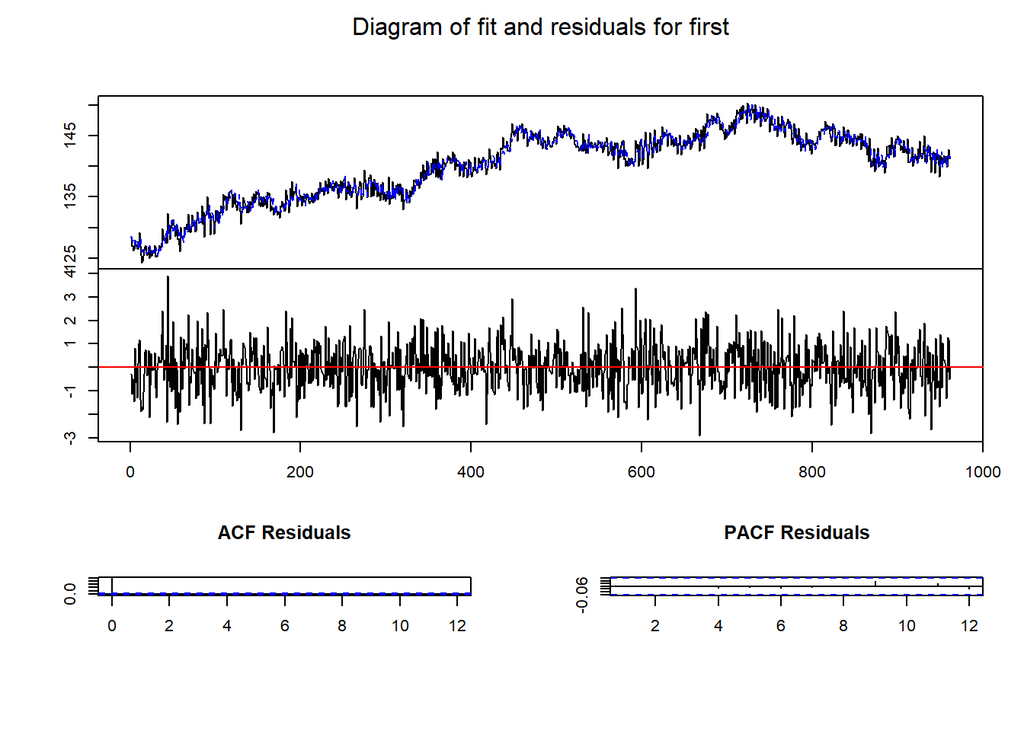

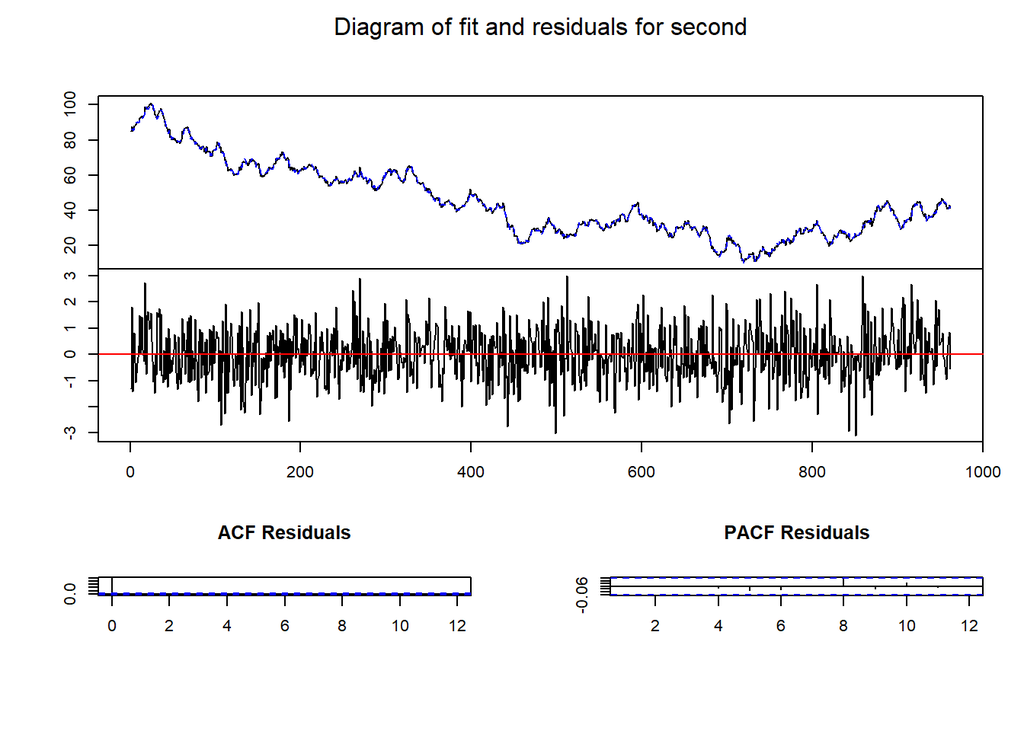

```r
plot(VAR_model_8_lags)
```

ACF and PACF in both cases looks good

**lets look at the residuals**

```r
serial.test(VAR_model_6_lags)
```

```
##
##  Portmanteau Test (asymptotic)
##
## data:  Residuals of VAR object VAR_model_6_lags
## Chi-squared = 53.873, df = 40, p-value = 0.07027
```

```r
serial.test(VAR_model_8_lags)
```

```
##
##  Portmanteau Test (asymptotic)
##
## data:  Residuals of VAR object VAR_model_8_lags
## Chi-squared = 39.202, df = 32, p-value = 0.1782
```

Both models show no autocorrelation in residuals

## AIC/BIC

```r
AIC(VAR_model_6_lags, VAR_model_8_lags)
```

```
##                  df      AIC
## VAR_model_6_lags 26 5573.656
## VAR_model_8_lags 34 5567.348
```

```r
BIC(VAR_model_6_lags, VAR_model_8_lags)
```

```
##                  df      BIC
## VAR_model_6_lags 26 5700.304
## VAR_model_8_lags 34 5732.895
```

AIC prefers model with 8 lags, but BIC prefers model with 6 lags, lets stick to 6 lags, because as we showed earlier adding more lags gives us nonsignificant variables

## IRF

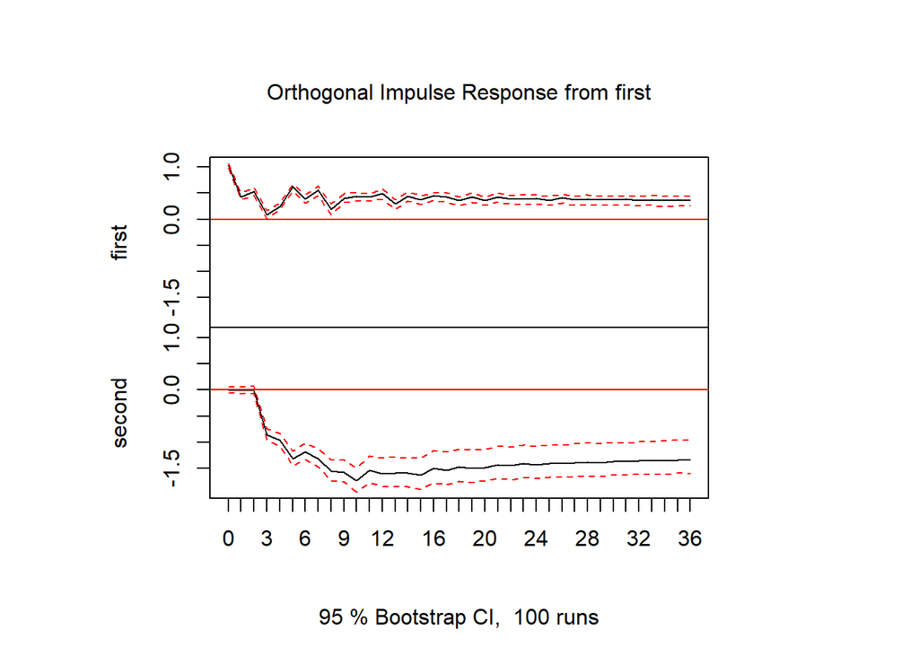

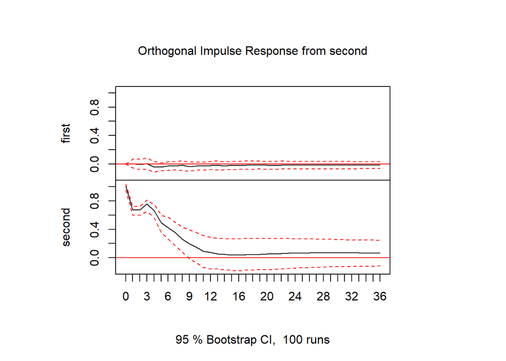

```r
plot(irf(VAR_model_6_lags, n.ahead = 36))
```

**First:**

**from first:**

- 0-3 shows initial shock in impact with downward trend until near impact level of 0.
- 3-10 shows variation in impact with following movements: 3-5 upward, 5-6 downward, 6-7 upward, 7-9 downward, 9-10 upward.
- The impact in first is fairly stable from period 10 and shows little variation from 0,5.

**from second:**

- Shock in impact with downward trend form 2 up to 10 period, since then the impact stays relatively stable with a low upward trend at around -1,5.

**Second:**

**from first:**

- The impact in first is fairly stable and showing little variation from 0 until period 16.

**from second:**

- 0-12 initial shock in impact for second up to 12 period, since then the impact stays stable at around 0,05.

## FEVD

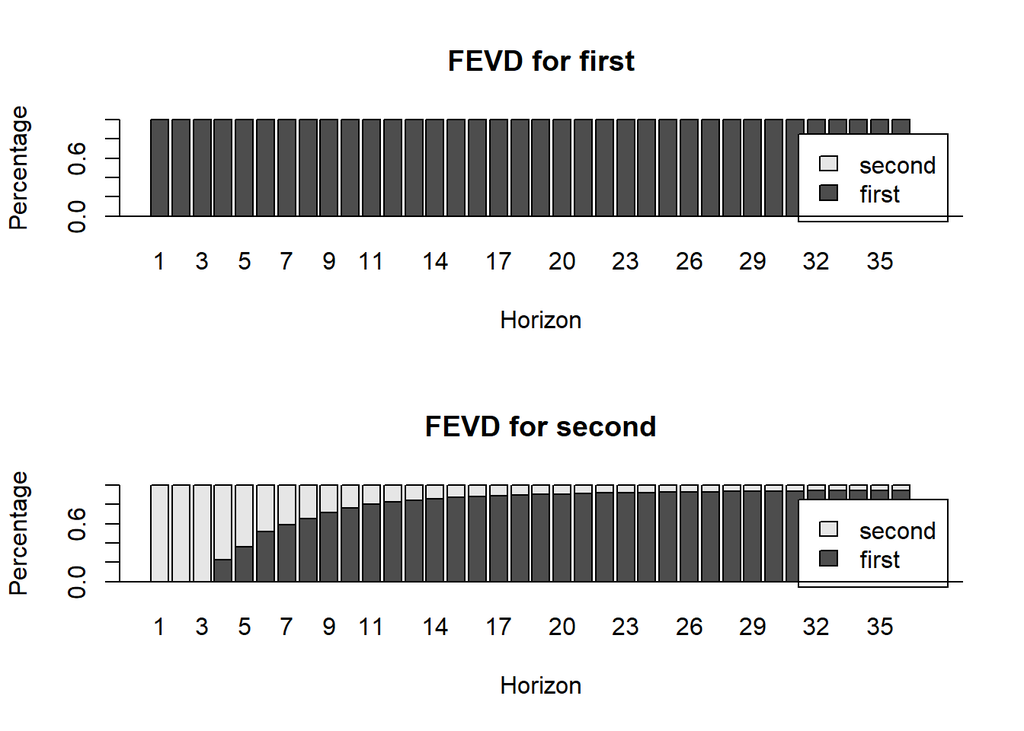

```r
plot(fevd(VAR_model_6_lags, n.ahead = 36))
```

**First:**

- Whole variation is from the first time series.
- the variation seems to be constant for first and for second.
- Overall the first shocks have much stronger impact on future values of first and second.

**Second:**

- In the initial periods from 1-3 whole variation is explained by second time series.
- The contribution of first to the variation for second changes fairly rapidly from 4-14.
- Afterwards the contribution of first to variation levels off at around 95%.
- Overall except initial state from 1-7 the first shocks have much stronger impact on future values of first and second.

## JOHANSON COINTEGRATION TEST

```r
johan.test.trace <-
  ca.jo(chosen_ones[,1:2],
        ecdet = "trend",
        type = "trace",  # type of the test: trace or eigen
        K = 6) # lags in VAR model
summary(johan.test.trace)
```

```
##
## ######################
## # Johansen-Procedure #
## ######################
##
## Test type: trace statistic , with linear trend in cointegration
##
## Eigenvalues (lambda):
## [1]  1.666721e-01  5.170895e-03 -2.232142e-18
##
## Values of teststatistic and critical values of test:
##
##            test 10pct  5pct  1pct
## r <= 1 |   5.00 10.49 12.25 16.26
## r = 0  | 180.76 22.76 25.32 30.45
##
## Eigenvectors, normalised to first column:
## (These are the cointegration relations)
##
##                first.l6   second.l6    trend.l6
## first.l6   1.0000000000  1.00000000  1.00000000
## second.l6  0.2728618658 -0.08640407 -0.24202669
## trend.l6  -0.0005680063 -0.01184080 -0.05989819
##
## Weights W:
## (This is the loading matrix)
##
##             first.l6     second.l6      trend.l6
## first.d  -0.04695642 -0.0145958173 -1.335917e-16
## second.d -0.76979667  0.0009499478 -2.095432e-15
```

```r
cbind(summary(johan.test.trace)@teststat, summary(johan.test.trace)@cval)
```

```
##                     10pct  5pct  1pct
## r <= 1 |   4.997675 10.49 12.25 16.26
## r = 0  | 180.761959 22.76 25.32 30.45
```

exactly one cointegrated vector

## change type to eigen

```r
johan.test.eigen <-
  ca.jo(chosen_ones[,1:2],
        ecdet = "trend",
        type = "eigen",  # type of the test: trace or eigen
        K = 6) # lags in VAR model
summary(johan.test.eigen)
```

```
##
## ######################
## # Johansen-Procedure #
## ######################
##
## Test type: maximal eigenvalue statistic (lambda max) , with linear trend in cointegration
##
## Eigenvalues (lambda):
## [1]  1.666721e-01  5.170895e-03 -2.232142e-18
##
## Values of teststatistic and critical values of test:
##
##            test 10pct  5pct  1pct
## r <= 1 |   5.00 10.49 12.25 16.26
## r = 0  | 175.76 16.85 18.96 23.65
##
## Eigenvectors, normalised to first column:
## (These are the cointegration relations)
##
##                first.l6   second.l6    trend.l6
## first.l6   1.0000000000  1.00000000  1.00000000
## second.l6  0.2728618658 -0.08640407 -0.24202669
## trend.l6  -0.0005680063 -0.01184080 -0.05989819
##
## Weights W:
## (This is the loading matrix)
##
##             first.l6     second.l6      trend.l6
## first.d  -0.04695642 -0.0145958173 -1.335917e-16
## second.d -0.76979667  0.0009499478 -2.095432e-15
```

```r
cbind(summary(johan.test.eigen)@teststat, summary(johan.test.eigen)@cval)
```

```
##                     10pct  5pct  1pct
## r <= 1 |   4.997675 10.49 12.25 16.26
## r = 0  | 175.764284 16.85 18.96 23.65
```

same interpretation

# VECM

```r
VECM_model <- cajorls(johan.test.trace, # defined specification
                                     r = 1) # number of cointegrating vectors

summary(VECM_model$rlm)
```

```
## Response first.d :
##
## Call:
## lm(formula = first.d ~ ect1 + constant + first.dl1 + second.dl1 +
##     first.dl2 + second.dl2 + first.dl3 + second.dl3 + first.dl4 +
##     second.dl4 + first.dl5 + second.dl5 - 1, data = data.mat)
##
## Residuals:
##     Min      1Q  Median      3Q     Max
## -2.8686 -0.7046  0.0092  0.7222  3.9860
##
## Coefficients:
##                Estimate   Std. Error t value           Pr(>|t|)
## ect1       -0.046956418  0.057396797  -0.818           0.413504
## constant    7.167130549  8.721478468   0.822           0.411408
## first.dl1  -0.583178042  0.031883590 -18.291            < 2e-16 ***
## second.dl1  0.002250134  0.033026969   0.068           0.945696
## first.dl2  -0.232788539  0.036027700  -6.461 0.0000000001653454 ***
## second.dl2 -0.012580416  0.034241118  -0.367           0.713397
## first.dl3  -0.504948425  0.035359726 -14.280            < 2e-16 ***
## second.dl3  0.000001216  0.032800520   0.000           0.999970
## first.dl4  -0.363628214  0.047026102  -7.732 0.0000000000000268 ***
## second.dl4 -0.044376078  0.026802621  -1.656           0.098120 .
## first.dl5   0.182621881  0.055238501   3.306           0.000982 ***
## second.dl5 -0.044619332  0.025870443  -1.725           0.084902 .
## ---
## Signif. codes:  0 '***' 0.001 '**' 0.01 '*' 0.05 '.' 0.1 ' ' 1
##
## Residual standard error: 1.033 on 952 degrees of freedom
## Multiple R-squared:  0.5066, Adjusted R-squared:  0.5004
## F-statistic: 81.47 on 12 and 952 DF,  p-value: < 2.2e-16
##
##
## Response second.d :
##
## Call:
## lm(formula = second.d ~ ect1 + constant + first.dl1 + second.dl1 +
##     first.dl2 + second.dl2 + first.dl3 + second.dl3 + first.dl4 +
##     second.dl4 + first.dl5 + second.dl5 - 1, data = data.mat)
##
```

[output cut: 9 more lines]

```
## second.dl1  -0.339009   0.032172 -10.537  < 2e-16 ***
## first.dl2   -0.006659   0.035095  -0.190 0.849557
## second.dl2  -0.115887   0.033355  -3.474 0.000535 ***
## first.dl3   -0.828725   0.034445 -24.060  < 2e-16 ***
## second.dl3   0.040346   0.031952   1.263 0.207002
## first.dl4   -0.877212   0.045809 -19.149  < 2e-16 ***
## second.dl4  -0.052436   0.026109  -2.008 0.044891 *
## first.dl5   -0.910773   0.053809 -16.926  < 2e-16 ***
## second.dl5  -0.219252   0.025201  -8.700  < 2e-16 ***
## ---
## Signif. codes:  0 '***' 0.001 '**' 0.01 '*' 0.05 '.' 0.1 ' ' 1
##
## Residual standard error: 1.006 on 952 degrees of freedom
## Multiple R-squared:  0.5517, Adjusted R-squared:  0.546
## F-statistic: 97.62 on 12 and 952 DF,  p-value: < 2.2e-16
```

```r
VECM_model$beta
```

```
##                    ect1
## first.l6   1.0000000000
## second.l6  0.2728618658
## trend.l6  -0.0005680063
```

We can reparametrize the VEC model into VAR (here we use the specification object):

```r
VECM_model.asVAR <- vec2var(johan.test.trace, r = 1)
```

**Check the results**

```r
VECM_model.asVAR
```

```
##
## Coefficient matrix of lagged endogenous variables:
##
## A1:
##            first.l1   second.l1
## first   0.416821958 0.002250134
## second -0.007395418 0.660990545
##
##
## A2:
##           first.l2   second.l2
## first  0.350389502 -0.01483055
## second 0.000736555  0.22312261
##
##
## A3:
##          first.l3  second.l3
## first  -0.2721599 0.01258163
## second -0.8220666 0.15623277
##
##
## A4:
##           first.l4   second.l4
## first   0.14132021 -0.04437729
## second -0.04848673 -0.09278154
##
##
## A5:
##           first.l5     second.l5
## first   0.54625010 -0.0002432543
## second -0.03356104 -0.1668167342
##
##
## A6:
##          first.l6   second.l6
## first  -0.2295783 0.031806716
## second  0.1409766 0.009204185
##
##
## Coefficient matrix of deterministic regressor(s).
##
##          constant      trend.l6
## first    7.167131 0.00002667154
## second 116.961298 0.00043724938
```

Based on the reparametrized model, we can calculate and plot Impulse Response Functions:

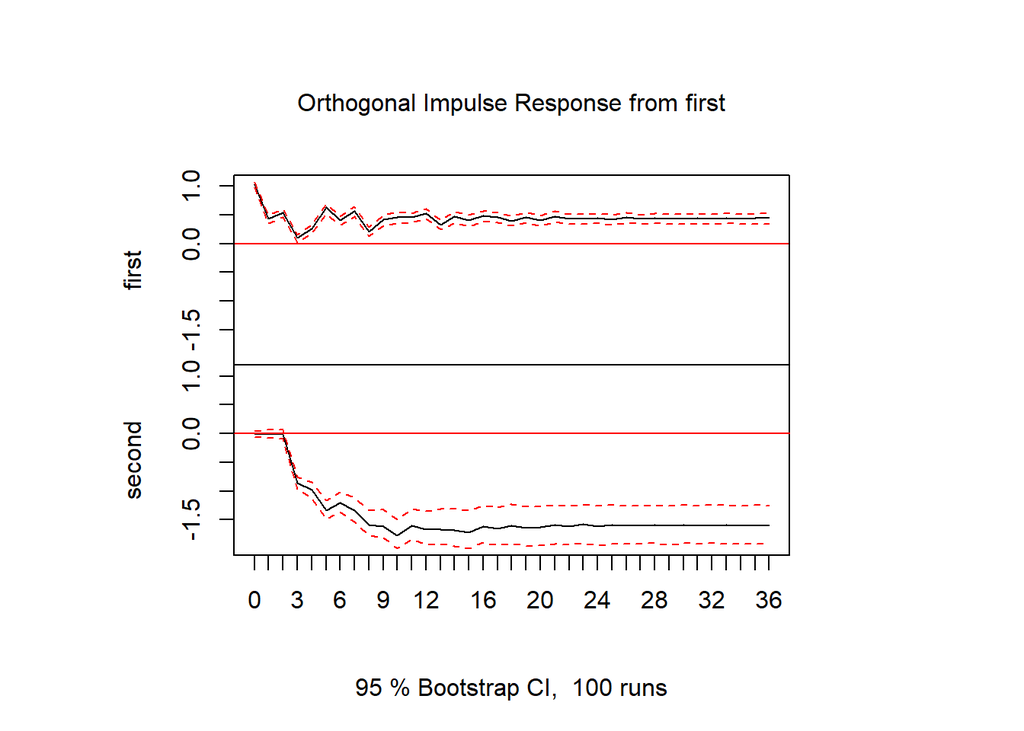

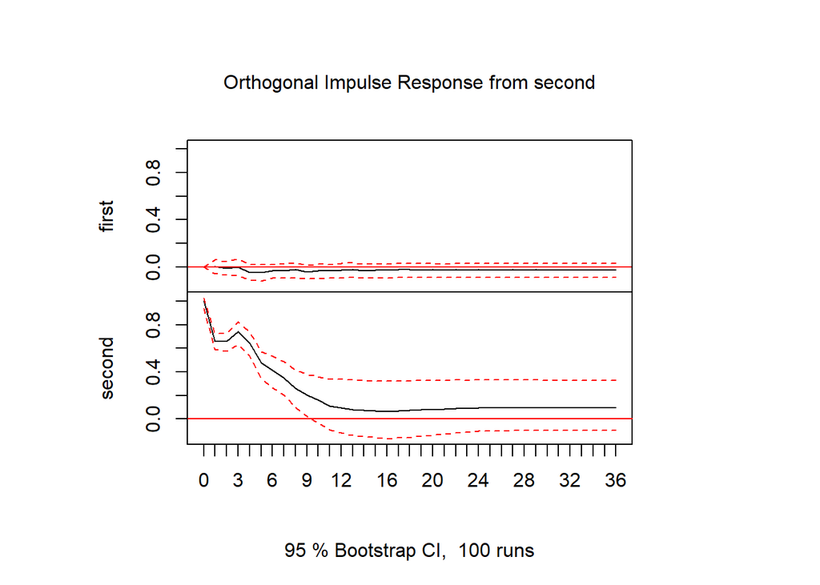

```r
plot(irf(VECM_model.asVAR, n.ahead = 36))
```

The results are pretty similar to the earlier `VAR(6)` model with only difference being:

**for first:**

- In second there is a difference where from 24 period the results are completely stable at impact level around -1,5

**for second:**

- Slightly decreased level of impact in first making it below zero
- Higher result in second leaving it slightly above 0,05.

We can also perform variance decomposition:

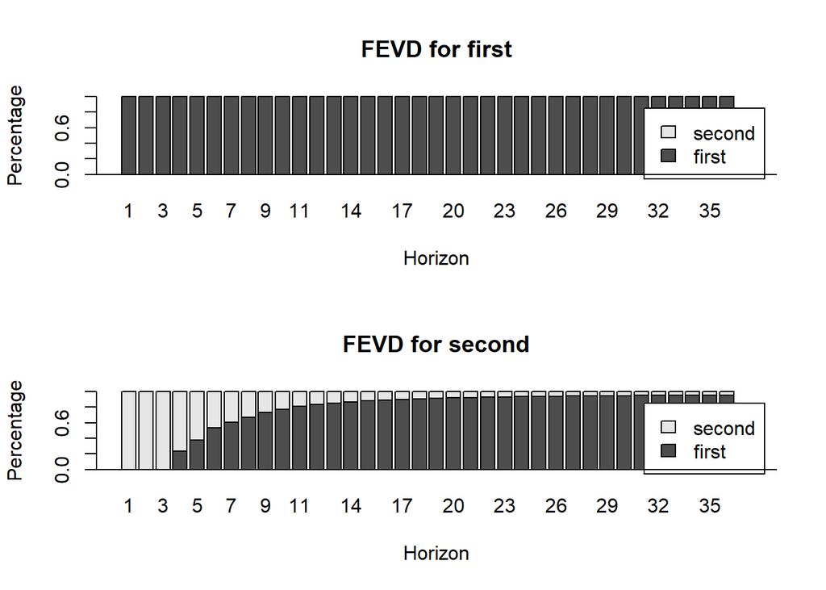

```r
plot(fevd(VECM_model.asVAR, n.ahead = 36))
```

The results are pretty similar to the earlier `VAR(6)` model.

Let’s also check if model residuals are autocorrelated.

Residuals can be extracted only from the VAR reparametrized model.

```r
head(residuals(VECM_model.asVAR))
```

```
##            resids of first resids of second
## 2018-04-11      0.05909339        0.4395122
## 2018-04-12      0.14239066       -0.7592602
## 2018-04-13     -0.16290562       -1.3463948
## 2018-04-14     -0.94460219        1.7291935
## 2018-04-15     -0.28655976       -1.4550074
## 2018-04-16     -1.10194525        0.8186101
```

```r
serial.test(VECM_model.asVAR)
```

```
##
##  Portmanteau Test (asymptotic)
##
## data:  Residuals of VAR object VECM_model.asVAR
## Chi-squared = 53.346, df = 42, p-value = 0.1126
```

The null is not rejected, residuals are not autocorrelated.

You can see the ACF and PACF functions by plotting the results of the `serial.test()`

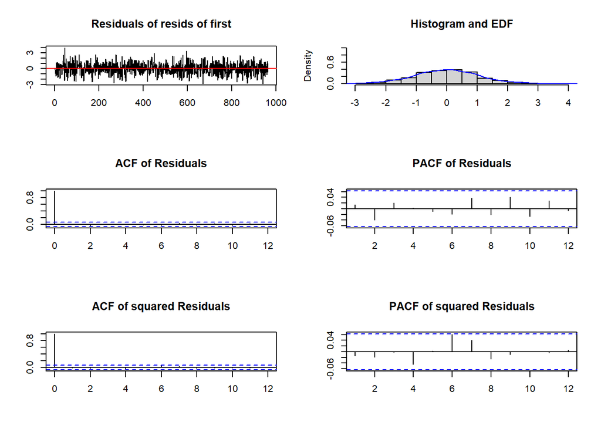

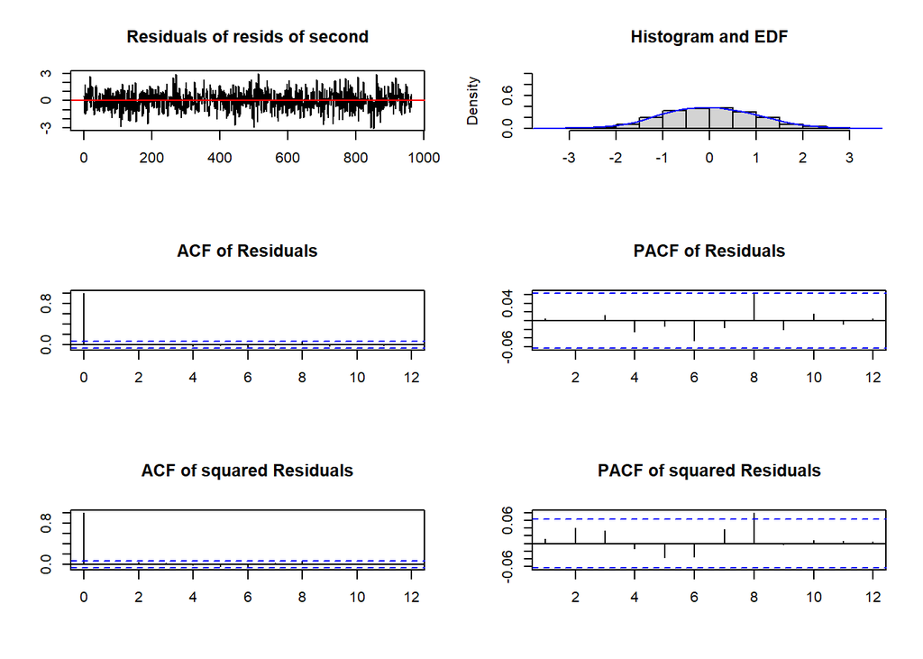

```r
plot(serial.test(VECM_model.asVAR))
```

8 lag in PACF of residuals and squared Residuals in second model seems significant

lets plot EDF (Empirical Distribution Function) better

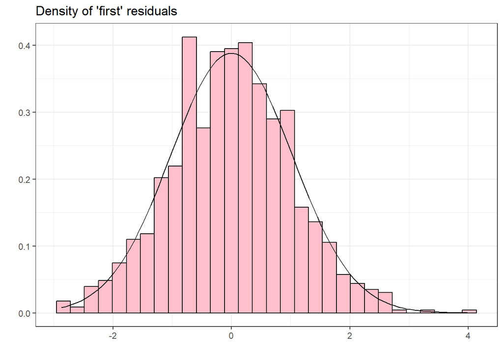

```r
VECM_model.asVAR %>%
  residuals() %>%
  as_tibble() %>%
  ggplot(aes(`resids of first`)) +
  geom_histogram(aes(y =..density..),
                 colour = "black",
                 fill = "pink") +
  stat_function(fun = dnorm,
                args = list(mean = mean(residuals(VECM_model.asVAR)[, 1]),
                            sd = sd(residuals(VECM_model.asVAR)[, 1]))) +
  theme_bw() +
  labs(
    title = "Density of 'first' residuals",
    y = "", x = ""
  )
```

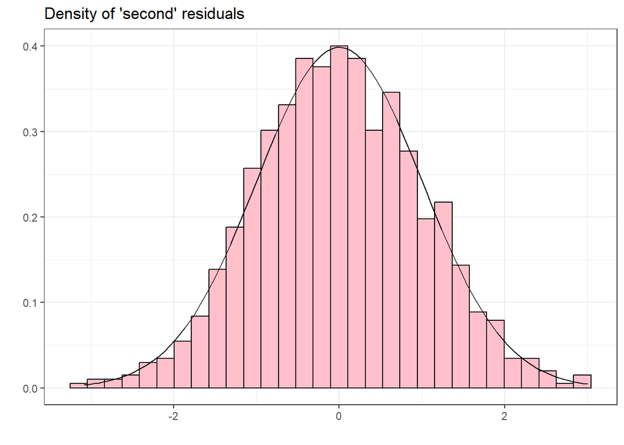

```r
VECM_model.asVAR %>%
  residuals() %>%
  as_tibble() %>%
  ggplot(aes(`resids of second`)) +
  geom_histogram(aes(y =..density..),
                 colour = "black",
                 fill = "pink") +
  stat_function(fun = dnorm,
                args = list(mean = mean(residuals(VECM_model.asVAR)[, 2]),
                            sd = sd(residuals(VECM_model.asVAR)[, 2]))) +
  theme_bw() +
  labs(
    title = "Density of 'second' residuals",
    y = "", x = ""
  )
```

#### Use Jarque-Bera multivariate test to check for normality in residuals

```r
normality.test(VECM_model.asVAR)
```

```
## $JB
##
##  JB-Test (multivariate)
##
## data:  Residuals of VAR object VECM_model.asVAR
## Chi-squared = 1.8527, df = 4, p-value = 0.7628
##
##
## $Skewness
##
##  Skewness only (multivariate)
##
## data:  Residuals of VAR object VECM_model.asVAR
## Chi-squared = 1.0887, df = 2, p-value = 0.5802
##
##
## $Kurtosis
##
##  Kurtosis only (multivariate)
##
## data:  Residuals of VAR object VECM_model.asVAR
## Chi-squared = 0.76399, df = 2, p-value = 0.6825
```

null about normality is **not rejected!!!**

```r
VECM_model.asVAR.fore <-
  predict(
    VECM_model.asVAR,     # no of cointegrating vectors
    n.ahead = 30, # forecast horizon
    ci = 0.95)
```

# VECM forecasts for *first*:

```r
VECM_model.asVAR.fore$fcst$first
```

```
##           fcst    lower    upper       CI
##  [1,] 140.3893 138.3771 142.4014 2.012120
##  [2,] 141.6711 139.4912 143.8511 2.179909
##  [3,] 141.8194 139.3976 144.2412 2.421799
##  [4,] 141.5767 139.1477 144.0056 2.428932
##  [5,] 141.4512 138.9694 143.9329 2.481758
##  [6,] 140.9417 138.1722 143.7112 2.769508
##  [7,] 141.6571 138.7783 144.5358 2.878745
##  [8,] 141.5406 138.4535 144.6277 3.087142
##  [9,] 141.7097 138.5944 144.8251 3.115340
## [10,] 141.4886 138.2662 144.7109 3.222334
## [11,] 141.3265 137.9801 144.6729 3.346419
## [12,] 141.6258 138.1633 145.0884 3.462562
## [13,] 141.5258 137.9164 145.1351 3.609356
## [14,] 141.7379 138.0737 145.4021 3.664170
```

[output cut: 16 more lines]

# VECM forecasts for *second*:

```r
VECM_model.asVAR.fore$fcst$second
```

```
##           fcst    lower    upper        CI
##  [1,] 40.42097 38.46091 42.38102  1.960055
##  [2,] 40.64193 38.29228 42.99158  2.349648
##  [3,] 40.45978 37.77745 43.14211  2.682332
##  [4,] 41.07838 37.59439 44.56236  3.483985
##  [5,] 40.64255 36.47340 44.81171  4.169155
##  [6,] 40.40531 35.39548 45.41514  5.009827
##  [7,] 40.25704 34.65625 45.85782  5.600786
##  [8,] 40.29846 34.07313 46.52379  6.225328
##  [9,] 40.64701 33.66721 47.62681  6.979795
## [10,] 40.36963 32.69523 48.04404  7.674408
## [11,] 40.38252 31.94642 48.81863  8.436105
## [12,] 40.17457 31.17077 49.17836  9.003798
## [13,] 40.23251 30.65205 49.81296  9.580457
## [14,] 40.31766 30.19639 50.43893 10.121270
```

[output cut: 16 more lines]

### Forecasts

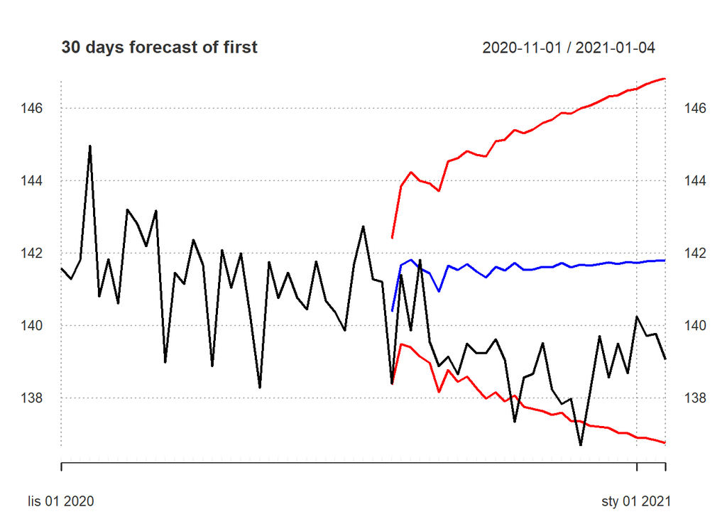

```r
VECM_first_forecast <- xts(VECM_model.asVAR.fore$fcst$first[,-4], order.by = data_test$X)

VECM_second_forecast <- xts(VECM_model.asVAR.fore$fcst$second[,-4], order.by = data_test$X)


names(VECM_first_forecast) <- c("first_fore", "first_lower", "first_upper")

names(VECM_second_forecast) <- c("second_fore", "second_lower", "second_upper")


VECM_first_all_data <- merge(data_all_xts,
                             data_all_second_xts,
                             VECM_first_forecast,
                             VECM_second_forecast)

plot(VECM_first_all_data["2020-11/", c("first", "first_fore",
                        "first_lower", "first_upper")],
     major.ticks = "years",
     grid.ticks.on = "years",
     grid.ticks.lty = 3,
     main = "30 days forecast of first",
     col = c("black", "blue", "red", "red"))
```

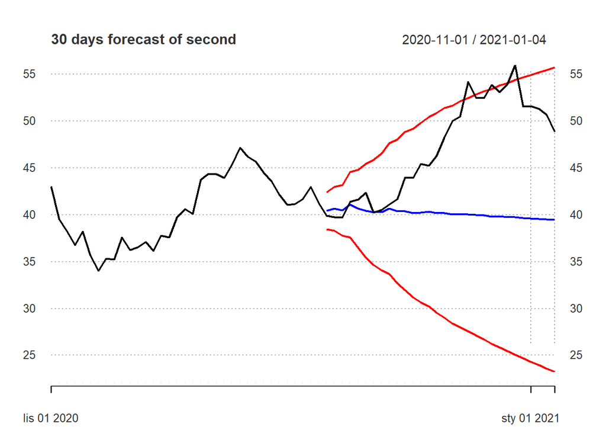

```r
plot(VECM_first_all_data["2020-11/", c("second", "second_fore",
                        "second_lower", "second_upper")],
     major.ticks = "years",
     grid.ticks.on = "years",
     grid.ticks.lty = 3,
     main = "30 days forecast of second",
     col = c("black", "blue", "red", "red"))
```

# WITH ARIMA MODELS

```r
forecasts_first_all <- merge(ARIMA_forecasts_first,
                             VECM_first_forecast)

forecasts_second_all <- merge(ARIMA_forecasts_second,
                             VECM_second_forecast)
```

### First

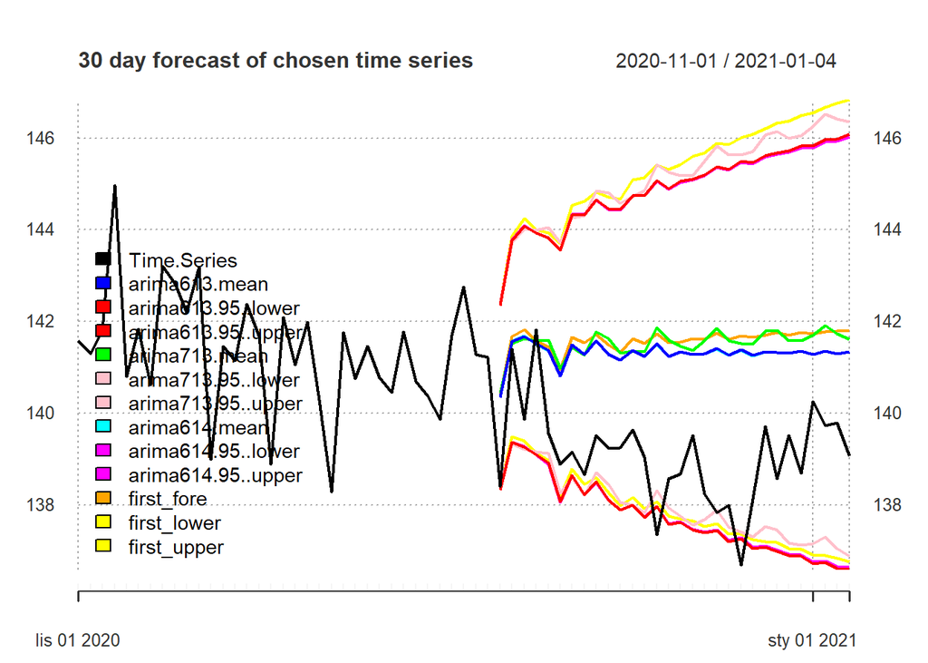

```r
plot(forecasts_first_all["2020-11/",],
     major.ticks = "years",
     grid.ticks.on = "years",
     grid.ticks.lty = 3,
     main = "30 day forecast of chosen time series",
     col = c("black", "blue", "red", "red", "green", "pink", "pink", "cyan", "magenta", "magenta", "orange", "yellow", "yellow"),
     legend.loc = "bottomleft")
```

### Second

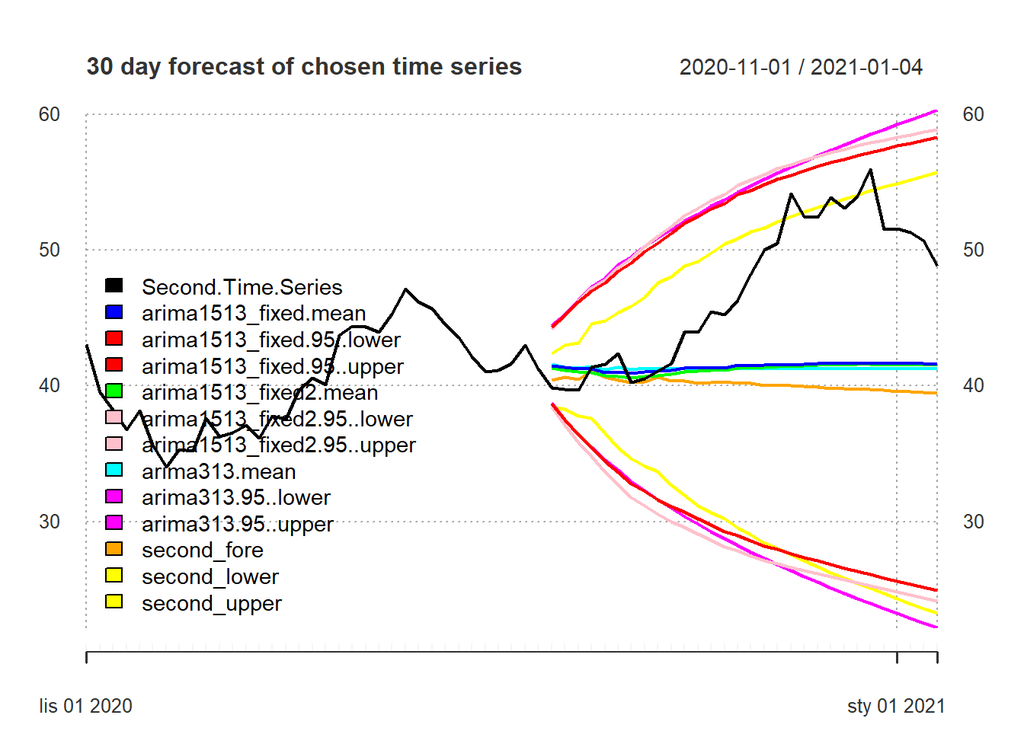

```r
plot(forecasts_second_all["2020-11/",],
     major.ticks = "years",
     grid.ticks.on = "years",
     grid.ticks.lty = 3,
     main = "30 day forecast of chosen time series",
     col = c("black", "blue", "red", "red", "green", "pink", "pink", "cyan", "magenta", "magenta", "orange", "yellow", "yellow"),
     legend.loc = "bottomleft")
```

# EX POST ERRORS

```r
names(forecasts_first_all)
```

```
##  [1] "Time.Series"        "arima613.mean"      "arima613.95..lower"
##  [4] "arima613.95..upper" "arima713.mean"      "arima713.95..lower"
##  [7] "arima713.95..upper" "arima614.mean"      "arima614.95..lower"
## [10] "arima614.95..upper" "first_fore"         "first_lower"
## [13] "first_upper"
```

```r
names(forecasts_second_all)
```

```
##  [1] "Second.Time.Series"         "arima1513_fixed.mean"
##  [3] "arima1513_fixed.95..lower"  "arima1513_fixed.95..upper"
##  [5] "arima1513_fixed2.mean"      "arima1513_fixed2.95..lower"
##  [7] "arima1513_fixed2.95..upper" "arima313.mean"
##  [9] "arima313.95..lower"         "arima313.95..upper"
## [11] "second_fore"                "second_lower"
## [13] "second_upper"
```

## First

```r
errors_first_ts <- {}
```

### ARIMA(6,1,3)

```r
errors_first_ts$arima613mae   <-  mae(forecasts_first_all[971:1000,1],forecasts_first_all$arima613.mean)
errors_first_ts$arima613mse   <-  mse(forecasts_first_all[971:1000,1],forecasts_first_all$arima613.mean)
errors_first_ts$arima613mape  <-  mape(forecasts_first_all[971:1000,1],forecasts_first_all$arima613.mean)
errors_first_ts$arima613amape <-  mean(abs((forecasts_first_all[971:1000,1] - forecasts_first_all$arima613.mean) /
                                        (forecasts_first_all[971:1000,1] + forecasts_first_all$arima613.mean)))
```

### ARIMA(7,1,3)

```r
errors_first_ts$arima713mae   <-  mae(forecasts_first_all[971:1000,1],forecasts_first_all$arima713.mean)
errors_first_ts$arima713mse   <-  mse(forecasts_first_all[971:1000,1],forecasts_first_all$arima713.mean)
errors_first_ts$arima713mape  <-  mape(forecasts_first_all[971:1000,1],forecasts_first_all$arima713.mean)
errors_first_ts$arima713amape <-  mean(abs((forecasts_first_all[971:1000,1] - forecasts_first_all$arima713.mean) /
                                             (forecasts_first_all[971:1000,1] + forecasts_first_all$arima713.mean)))
```

### ARIMA(6,1,4)

```r
errors_first_ts$arima614mae   <-  mae(forecasts_first_all[971:1000,1],forecasts_first_all$arima614.mean)
errors_first_ts$arima614mse   <-  mse(forecasts_first_all[971:1000,1],forecasts_first_all$arima614.mean)
errors_first_ts$arima614mape  <-  mape(forecasts_first_all[971:1000,1],forecasts_first_all$arima614.mean)
errors_first_ts$arima614amape <-  mean(abs((forecasts_first_all[971:1000,1] - forecasts_first_all$arima614.mean) /
                                             (forecasts_first_all[971:1000,1] + forecasts_first_all$arima614.mean)))
```

### VECM

```r
errors_first_ts$VECM_mae   <-  mae(forecasts_first_all[971:1000,1],forecasts_first_all$first_fore)
errors_first_ts$VECM_mse   <-  mse(forecasts_first_all[971:1000,1],forecasts_first_all$first_fore)
errors_first_ts$VECM_mape  <-  mape(forecasts_first_all[971:1000,1],forecasts_first_all$first_fore)
errors_first_ts$VECM_amape <-  mean(abs((forecasts_first_all[971:1000,1] - forecasts_first_all$first_fore) /
                                             (forecasts_first_all[971:1000,1] + forecasts_first_all$first_fore)))

errors_first_ts
```

```
## $arima613mae
## [1] 2.237853
##
## $arima613mse
## [1] 5.9145
##
## $arima613mape
## [1] 0.01613899
##
## $arima613amape
## [1] 0.007993144
##
## $arima713mae
## [1] 2.455541
##
## $arima713mse
## [1] 7.049397
##
## $arima713mape
## [1] 0.01770667
##
## $arima713amape
## [1] 0.008762416
##
## $arima614mae
## [1] 2.236167
##
## $arima614mse
## [1] 5.903178
##
## $arima614mape
## [1] 0.01612676
##
## $arima614amape
## [1] 0.007987179
##
## $VECM_mae
## [1] 2.509004
##
## $VECM_mse
## [1] 7.293876
##
## $VECM_mape
## [1] 0.01809064
##
## $VECM_amape
## [1] 0.008951276
```

### MAE

```r
errors_first_ts$arima613mae
```

```
## [1] 2.237853
```

```r
errors_first_ts$arima713mae
```

```
## [1] 2.455541
```

```r
errors_first_ts$arima614mae
```

```
## [1] 2.236167
```

```r
errors_first_ts$VECM_mae
```

```
## [1] 2.509004
```

arima(6,1,4) the best in terms of MAE

### MSE

```r
errors_first_ts$arima613mse
```

```
## [1] 5.9145
```

```r
errors_first_ts$arima713mse
```

```
## [1] 7.049397
```

```r
errors_first_ts$arima614mse
```

```
## [1] 5.903178
```

```r
errors_first_ts$VECM_mse
```

```
## [1] 7.293876
```

arima(6,1,4) the best in terms of MSE

### MAPE

```r
errors_first_ts$arima613mape
```

```
## [1] 0.01613899
```

```r
errors_first_ts$arima713mape
```

```
## [1] 0.01770667
```

```r
errors_first_ts$arima614mape
```

```
## [1] 0.01612676
```

```r
errors_first_ts$VECM_mape
```

```
## [1] 0.01809064
```

arima(6,1,4) the best in terms of MAPE

### AMAPE

```r
errors_first_ts$arima613amape
```

```
## [1] 0.007993144
```

```r
errors_first_ts$arima713amape
```

```
## [1] 0.008762416
```

```r
errors_first_ts$arima614amape
```

```
## [1] 0.007987179
```

```r
errors_first_ts$VECM_amape
```

```
## [1] 0.008951276
```

arima(6,1,4) the best in terms of AMAPE

## SECOND

```r
errors_second_ts <- {}
```

### ARIMA(15,1,3) fixed

```r
errors_second_ts$arima1513_fixed_mae   <-  mae(forecasts_second_all[971:1000,1],forecasts_second_all$arima1513_fixed.mean)
errors_second_ts$arima1513_fixed_mse   <-  mse(forecasts_second_all[971:1000,1],forecasts_second_all$arima1513_fixed.mean)
errors_second_ts$arima1513_fixed_mape  <-  mape(forecasts_second_all[971:1000,1],forecasts_second_all$arima1513_fixed.mean)
errors_second_ts$arima1513_fixed_amape <-  mean(abs((forecasts_second_all[971:1000,1] - forecasts_second_all$arima1513_fixed.mean) /
                                             (forecasts_second_all[971:1000,1] + forecasts_second_all$arima1513_fixed.mean)))
```

### ARIMA(15,1,3) fixed2

```r
errors_second_ts$arima1513_fixed2_mae   <-  mae(forecasts_second_all[971:1000,1],forecasts_second_all$arima1513_fixed2.mean)
errors_second_ts$arima1513_fixed2_mse   <-  mse(forecasts_second_all[971:1000,1],forecasts_second_all$arima1513_fixed2.mean)
errors_second_ts$arima1513_fixed2_mape  <-  mape(forecasts_second_all[971:1000,1],forecasts_second_all$arima1513_fixed2.mean)
errors_second_ts$arima1513_fixed2_amape <-  mean(abs((forecasts_second_all[971:1000,1] - forecasts_second_all$arima1513_fixed2.mean) /
                                                     (forecasts_second_all[971:1000,1] + forecasts_second_all$arima1513_fixed2.mean)))
```

### ARIMA(3,1,3)

```r
errors_second_ts$arima313_mae   <-  mae(forecasts_second_all[971:1000,1],forecasts_second_all$arima313.mean)
errors_second_ts$arima313_mse   <-  mse(forecasts_second_all[971:1000,1],forecasts_second_all$arima313.mean)
errors_second_ts$arima313_mape  <-  mape(forecasts_second_all[971:1000,1],forecasts_second_all$arima313.mean)
errors_second_ts$arima313_amape <-  mean(abs((forecasts_second_all[971:1000,1] - forecasts_second_all$arima313.mean) /
                                                     (forecasts_second_all[971:1000,1] + forecasts_second_all$arima313.mean)))
```

### VECM

```r
errors_second_ts$VECM_mae   <-  mae(forecasts_second_all[971:1000,1],forecasts_second_all$second_fore)
errors_second_ts$VECM_mse   <-  mse(forecasts_second_all[971:1000,1],forecasts_second_all$second_fore)
errors_second_ts$VECM_mape  <-  mape(forecasts_second_all[971:1000,1],forecasts_second_all$second_fore)
errors_second_ts$VECM_amape <-  mean(abs((forecasts_second_all[971:1000,1] - forecasts_second_all$second_fore) /
                                              (forecasts_second_all[971:1000,1] + forecasts_second_all$second_fore)))
```

### MAE

```r
errors_second_ts$arima1513_fixed_mae
```

```
## [1] 6.03354
```

```r
errors_second_ts$arima1513_fixed2_mae
```

```
## [1] 6.128942
```

```r
errors_second_ts$arima313_mae
```

```
## [1] 6.244858
```

```r
errors_second_ts$VECM_mae
```

```
## [1] 7.083872
```

ARIMA(15,1,3) fixed best in terms of MAE

### MSE

```r
errors_second_ts$arima1513_fixed_mse
```

```
## [1] 57.62299
```

```r
errors_second_ts$arima1513_fixed2_mse
```

```
## [1] 58.94549
```

```r
errors_second_ts$arima313_mse
```

```
## [1] 61.7625
```

```r
errors_second_ts$VECM_mse
```

```
## [1] 79.43781
```

ARIMA(15,1,3) fixed best in terms of MSE

### MAPE

```r
errors_second_ts$arima1513_fixed_mape
```

```
## [1] 0.1189137
```

```r
errors_second_ts$arima1513_fixed2_mape
```

```
## [1] 0.120852
```

```r
errors_second_ts$arima313_mape
```

```
## [1] 0.1230825
```

```r
errors_second_ts$VECM_mape
```

```
## [1] 0.1393961
```

ARIMA(15,1,3) fixed best in terms of MAPE

### AMAPE

```r
errors_second_ts$arima1513_fixed_amape
```

```
## [1] 0.06526256
```

```r
errors_second_ts$arima1513_fixed2_amape
```

```
## [1] 0.06640735
```

```r
errors_second_ts$arima313_amape
```

```
## [1] 0.06778333
```

```r
errors_second_ts$VECM_amape
```

```
## [1] 0.07799252
```

ARIMA(15,1,3) fixed best in terms of AMAPE

### Conclusion

We chose the third and ninth time series to model and forecast using ARIMA and VECM. Both of them are integrated of order 1 and we found their cointegrated vector. When analyzing ACF and PACF graphs to chose proper orders of q and p for ARIMA models, we concluded that in those time series there are no seasonal patterns, which was later confirmed when by statistically insignificance in seasonal variables in VAR models (there were some statistical evidence of seasonality, but only for single seasonal variables and in one time series mostly, they were also near the significance line (p-value of 0.05)).

For ARIMA models we followed Box-Jenkins procedure, but we also started by creating ARIMA(1,1,1) model for both time series in order to set up some benchmark. When following Box-Jenkins procedure, we tried to have low orders of p and q (so the model will be more theoretical), but when ACF and PACF showed some correlations, we also check higher orders of p and q (which made the models more atheoretical).

For VECM, firstly we checked for Granger causality, from which we could conclude that both time series influences (causes) each other. Secondly, we checked information criterias in order to select the proper lag lenght of the VAR model, which will be used to create VECM model. We also plotted Impulse Response Function (IRF) and Forecast Error Variance Decomposition (FEVD).

After selecting models with the smallest values of Information Criterias, we forecasted 30 next periods and plotted them with they upper and lower bands (95%), and calculated ex-post errors (MAE, MSE, MAPE, AMAPE). For the third time series the ARIMA(6,1,4) turn out to be the best (smallest ex-post errors), and for ninth time series, the ARIMA(15,1,3) turned out to be the best (smallest ex-post errors). For those time series it turns out that ARIMA models are performing better than VECM.